# Practica Final Modulo 5. Victor Manuel Ferreira Martinez

- Paquetes necesarios:

```r
library(summarytools)
library(ggplot2)
library(gmodels)
library(DataExplorer)
library(tidyverse)
library(visdat)
library(normtest)
library(car)
library(kableExtra)
library(corrplot)
library(nortest)
library(MASS)
library(caret)
```

- Tras cargar los diferentes paquetes, pasamos a elegir dataframe y hacer una pequeña introducción del mismo.

#### INTRODUCCION BASE DE DATOS

La base de datos utilizada es un dataset donde vienen recogidas las mediciones relacionadas con el **Indice de Desarrollo Humano** y la **Huella Ecológica Total** de 188 paises, que se encuentra dentro del plan de las naciones unidas de medición al desarrollo, y que se puede encontrar en (https://www.kaggle.com/footprintnetwork/ecological-footprint). Los datos pertenecen a las mediciones de 2016. Le daremos en primera estancia el nombre de huella_eco. Detallar que hemos optado en cargar el paquete desde el entorno de R, y que el nombre que recibe es countries.

```r
setwd("C:/Users/Propioetario/Desktop/Master Businees Analytics and Data Science/Modulo 5. Estadistica para cientifico de datos/RStudio/Tema5 Estadistica")
```

```r
countries <- read_csv('countries.csv')
countries
```

| Country | Region | Population (millions) | HDI | GDP per Capita | Cropland Footprint | Grazing Footprint | Forest Footprint | Carbon Footprint | Fish Footprint | Total Ecological Footprint | Cropland | Grazing Land | Forest Land | Fishing Water | Urban Land | Total Biocapacity | Biocapacity Deficit or Reserve | Earths Required | Countries Required | Data Quality |
| --- | --- | --- | --- | --- | --- | --- | --- | --- | --- | --- | --- | --- | --- | --- | --- | --- | --- | --- | --- | --- |
| Afghanistan | Middle East/Central Asia | 29.820 | 0.460000 | $614.66 | 0.30 | 0.20 | 0.08 | 0.18 | 0.00 | 0.79 | 0.24 | 0.20 | 0.02 | 0.00 | 0.04 | 0.50 | -0.30 | 0.46 | 1.60000 | 6 |
| Albania | Northern/Eastern Europe | 3.160 | 0.730000 | $4,534.37 | 0.78 | 0.22 | 0.25 | 0.87 | 0.02 | 2.21 | 0.55 | 0.21 | 0.29 | 0.07 | 0.06 | 1.18 | -1.03 | 1.27 | 1.87000 | 6 |
| Algeria | Africa | 38.480 | 0.730000 | $5,430.57 | 0.60 | 0.16 | 0.17 | 1.14 | 0.01 | 2.12 | 0.24 | 0.27 | 0.03 | 0.01 | 0.03 | 0.59 | -1.53 | 1.22 | 3.61000 | 5 |
| Angola | Africa | 20.820 | 0.520000 | $4,665.91 | 0.33 | 0.15 | 0.12 | 0.20 | 0.09 | 0.93 | 0.20 | 1.42 | 0.64 | 0.26 | 0.04 | 2.55 | 1.61 | 0.54 | 0.37000 | 6 |
| Antigua and Barbuda | Latin America | 0.090 | 0.780000 | $13,205.10 | NA | NA | NA | NA | NA | 5.38 | NA | NA | NA | NA | NA | 0.94 | -4.44 | 3.11 | 5.70000 | 2 |
| Argentina | Latin America | 41.090 | 0.830000 | $13,540.00 | 0.78 | 0.79 | 0.29 | 1.08 | 0.10 | 3.14 | 2.64 | 1.86 | 0.66 | 1.67 | 0.10 | 6.92 | 3.78 | 1.82 | 0.45000 | 6 |
| Armenia | Middle East/Central Asia | 2.970 | 0.730000 | $3,426.39 | 0.74 | 0.18 | 0.34 | 0.89 | 0.01 | 2.23 | 0.44 | 0.26 | 0.10 | 0.02 | 0.07 | 0.89 | -1.35 | 1.29 | 2.52000 | 3B |
| Aruba | Latin America | 0.100 | NA | NA | NA | NA | NA | NA | NA | 11.88 | NA | NA | NA | NA | NA | 0.57 | -11.31 | 6.86 | 20.69000 | 2 |
| Australia | Asia-Pacific | 23.050 | 0.930000 | $66,604.20 | 2.68 | 0.63 | 0.89 | 4.85 | 0.11 | 9.31 | 5.42 | 5.81 | 2.01 | 3.19 | 0.14 | 16.57 | 7.26 | 5.37 | 0.56000 | 5 |
| Austria | European Union | 8.460 | 0.880000 | $51,274.10 | 0.82 | 0.27 | 0.63 | 4.14 | 0.06 | 6.06 | 0.71 | 0.16 | 2.04 | 0.00 | 0.15 | 3.07 | -3.00 | 3.50 | 1.98000 | 5 |

[output cut: 178 more lines]

```r
huella_eco = countries
```

#### PASO 1. Definir un objetivo de estudio

1. ¿Qué problema se quiere solucionar con estos datos?;
2. ¿Qué significan las variables?;
3. ¿Que tipo de variables hay?
4. Definir un objetivo que ayude a solucionar el problema
5. La hipotesis planteada radica en demostrar la relación entre el Indice de desarrollo humano y la Huella Ecologica Total. Demostrar esta relación podría darnos diferentes aproximaciones. El Indice de Desarrollo Humano es un índice indicativo del nivel de desarrollo de un pais. Dicho nivel de desarrollo puede guardar una relación con la cantidad de huella ecológica necesaria para cada pais atendiendo al nivel de dicho índice. Por tanto, es planteable una reformulación de dicho indice, ya que de estar ligado a un mayor requerimiento ecológico podría indicar que este nivel de desarrollo tiene un coste que podria replantear la definición propia de desarrollo.

*2 y 3. Antes de pasar a definir todas las variables, se procede a hacer una pequeña visualización introductoria de las mismas.

```r
head(huella_eco,20)
```

| Country | Region | Population (millions) | HDI | GDP per Capita | Cropland Footprint | Grazing Footprint | Forest Footprint | Carbon Footprint | Fish Footprint | Total Ecological Footprint | Cropland | Grazing Land | Forest Land | Fishing Water | Urban Land | Total Biocapacity | Biocapacity Deficit or Reserve | Earths Required | Countries Required | Data Quality |
| --- | --- | --- | --- | --- | --- | --- | --- | --- | --- | --- | --- | --- | --- | --- | --- | --- | --- | --- | --- | --- |
| Afghanistan | Middle East/Central Asia | 29.82 | 0.46 | $614.66 | 0.30 | 0.20 | 0.08 | 0.18 | 0.00 | 0.79 | 0.24 | 0.20 | 0.02 | 0.00 | 0.04 | 0.50 | -0.30 | 0.46 | 1.60 | 6 |
| Albania | Northern/Eastern Europe | 3.16 | 0.73 | $4,534.37 | 0.78 | 0.22 | 0.25 | 0.87 | 0.02 | 2.21 | 0.55 | 0.21 | 0.29 | 0.07 | 0.06 | 1.18 | -1.03 | 1.27 | 1.87 | 6 |
| Algeria | Africa | 38.48 | 0.73 | $5,430.57 | 0.60 | 0.16 | 0.17 | 1.14 | 0.01 | 2.12 | 0.24 | 0.27 | 0.03 | 0.01 | 0.03 | 0.59 | -1.53 | 1.22 | 3.61 | 5 |
| Angola | Africa | 20.82 | 0.52 | $4,665.91 | 0.33 | 0.15 | 0.12 | 0.20 | 0.09 | 0.93 | 0.20 | 1.42 | 0.64 | 0.26 | 0.04 | 2.55 | 1.61 | 0.54 | 0.37 | 6 |
| Antigua and Barbuda | Latin America | 0.09 | 0.78 | $13,205.10 | NA | NA | NA | NA | NA | 5.38 | NA | NA | NA | NA | NA | 0.94 | -4.44 | 3.11 | 5.70 | 2 |
| Argentina | Latin America | 41.09 | 0.83 | $13,540.00 | 0.78 | 0.79 | 0.29 | 1.08 | 0.10 | 3.14 | 2.64 | 1.86 | 0.66 | 1.67 | 0.10 | 6.92 | 3.78 | 1.82 | 0.45 | 6 |
| Armenia | Middle East/Central Asia | 2.97 | 0.73 | $3,426.39 | 0.74 | 0.18 | 0.34 | 0.89 | 0.01 | 2.23 | 0.44 | 0.26 | 0.10 | 0.02 | 0.07 | 0.89 | -1.35 | 1.29 | 2.52 | 3B |
| Aruba | Latin America | 0.10 | NA | NA | NA | NA | NA | NA | NA | 11.88 | NA | NA | NA | NA | NA | 0.57 | -11.31 | 6.86 | 20.69 | 2 |
| Australia | Asia-Pacific | 23.05 | 0.93 | $66,604.20 | 2.68 | 0.63 | 0.89 | 4.85 | 0.11 | 9.31 | 5.42 | 5.81 | 2.01 | 3.19 | 0.14 | 16.57 | 7.26 | 5.37 | 0.56 | 5 |
| Austria | European Union | 8.46 | 0.88 | $51,274.10 | 0.82 | 0.27 | 0.63 | 4.14 | 0.06 | 6.06 | 0.71 | 0.16 | 2.04 | 0.00 | 0.15 | 3.07 | -3.00 | 3.50 | 1.98 | 5 |

[output cut: 10 more lines]

```r
dim(huella_eco)
```

```
## [1] 188  21
```

```r
ncol(huella_eco)
```

```
## [1] 21
```

```r
names(huella_eco)
```

```
##  [1] "Country"                        "Region"
##  [3] "Population (millions)"          "HDI"
##  [5] "GDP per Capita"                 "Cropland Footprint"
##  [7] "Grazing Footprint"              "Forest Footprint"
##  [9] "Carbon Footprint"               "Fish Footprint"
## [11] "Total Ecological Footprint"     "Cropland"
## [13] "Grazing Land"                   "Forest Land"
## [15] "Fishing Water"                  "Urban Land"
## [17] "Total Biocapacity"              "Biocapacity Deficit or Reserve"
## [19] "Earths Required"                "Countries Required"
## [21] "Data Quality"
```

- A partir de aquí se procede a hacer una descripcion de cada una de las variables, asi como indicar que tipo de variable son. Tras esto, se decidirá el objetivo en cuestión y que variables serán claves para la consecución del mismo.

**Country** - Nombre del pais - **VARIABLE CATEGORICA NOMINAL**

**Region** - Región a la que pertenece el pais - **VARIABLE CATEGORICA NOMINAL**

**Population** - Población en millones de habitantes - **VARIABLE CUANTITATIVA CONTINUA**

**Hdi - Indice de desarrollo humano** - Se trata de una variable nacida en el Programa de Naciones Unidas para el desarrollo, donde se tienen en cuenta tres variables diferentes para sacar un nivel de desarrollo estimado, destacando, la esperanza de vida, la educación, o el ingreso per capita. Puede tomar valores entre 0 y 1. Su calculo puede ser comprobado en (http://hdr.undp.org/en/data). Decir a que tipo de variable pertenece esta variable, puede ser confuso, pero la realidad es que entre 0 y 1, pueden tomar cualquier numero de valores, incontables. - **VARIABLE CUANTITATIVA CONTINUA**

Se trata de una variable categorizable, y que por tanto puede ser transformada en **VARIABLE CATEGORICA ORDINAL** con estos niveles ya estandarizados por las Naciones Unidas.

- Desarrollo humano muy alto (“High Human Development”), aquellos con niveles superiores al 0,80.
- Desarrollo humano alto (“Medium Human Development”), cuyos niveles rondan entre 0,70 y 0,80.
- Desarrollo humano medio (“Medium Human Development”), cuyos niveles rondan entre 0,55 y 0,70.
- Desarrollo humano bajo (“Low Human Development”), ya con una valoración inferior a 0,55

**Anotación** (Se utilizara esta anotación si finalmente trasformaramos dicha variable en una categorica ordinal).

**Gdp per Capita** - Relación entre el valor total de todos los bienes y servicios finales generados durante un año por la economía de una nación o estado y el número de sus habitantes en ese año. Puede ser expresado en valores de mercado o en valores básicos. Dicho de otra manera, es cantidad de riqueza total generada por un pais, que le corresponde a cada habitante de dicho pais - **VARIABLE CUANTITATIVA CONTINUA**

La tierra contiene 12.2 billones de hectareas productivas, que son categorizadas en 5 tipos, además, estas areas darian soporte a la demanda de los 5 tipos de huellas que aqui se describen.

**Cropland y Cropland Footprint** - - Cropland es la mas productiva de las areas usadas para producir comida y fibras de consumo humano, alimento para el ganado, aceite de cultivo y caucho.

- Cropland Footprint es la cantidad de hectareas que se requieren de Cropland para cubrir las necesidades generadas por el ser humano. **VARIABLES CUANTITATIVAS CONTINUAS**

**Grazing Land y Grazing Footprint** -  
-Grazing Land son las tierras de pastoreo utilizadas para criar ganado del que obtener carne, lacteos, piel y lana.

-Grazing Footprint de pastoreo se calcula comparando la cantidad de alimento para ganado disponible en un país con la cantidad de alimento requerida para todo el ganado en ese año, y se supone que el resto de la demanda de alimento proviene de las tierras de pastoreo. **VARIABLES CUANTITATIVAS CONTINUAS**

**Fishing Water y Fish Footprint** - La Huella de caladeros se calcula sobre la base de estimaciones de la captura máxima sostenible para una variedad de especies de peces. Estas estimaciones de captura sostenible se convierten en una masa equivalente de producción primaria basada en los niveles tróficos de las distintas especies. Esta estimación de la producción primaria máxima aprovechable se divide luego entre las áreas de la plataforma continental del mundo. Se incluye el pescado capturado y utilizado en mezclas de piensos para la acuicultura. **VARIABLES CUANTITATIVAS CONTINUAS**

**Forest Land y Forest Footprint** - Ofrecen dos servicios: La huella de productos forestales , que se calcula en función de la cantidad de madera, pulpa, productos de madera y leña consumida por un país anualmente. También tiene en cuenta la huella de carbono , que representa las emisiones de dióxido de carbono de la quema de combustibles fósiles. La Huella de Carbono también incluye el carbono incorporado en bienes importados. Está representado por el área necesaria para secuestrar estas emisiones de carbono. El componente Huella de carbono de la Huella ecológica se calcula como la cantidad de tierra forestal necesaria para absorber estas emisiones de dióxido de carbono. **VARIABLES CUANTITATIVAS CONTINUAS**

**Urban Land** - Se trata del area cubierta por infraestructura humana. Este area puede ocupar el area que anteriormente ha sido Cropland, y tiene un efecto sobre las mediciones echas en el data set. **VARIABLE CUANTITATIVA CONTINUA**

**Carbon Footprint**- La huella de carbono se mide en emisiones de C02 asociadas a la quema de combustibles fosiles. En terminos de huella ecológica, se trata de la cantidad de area productiva necesaria para absober la cantidad de CO2 que se emite. **VARIABLE CUANTITATIVA CONTINUA**

**Total Ecological Footprint** - Según W. Rees y M. Wackernagel (1995), la Huella Ecológica HE, es definida como “el área o territorio ecológicamente productivo (cultivos, pastos, bosques o ecosistema acuático) necesaria para producir los recursos utilizados y para asimilar los residuos producidos por una población definida con un nivel de vida específico indefinidamente, donde sea que se encuentre esta área”. En otras palabras, es un indicador biofísico delimpacto de una población determinada, de acuerdo con su estilo de vida y la productividad de su espacio físico, dados por los consumos y la tecnología utilizada - **VARIABLE CUANTITATIVA CONTINUA**

**Total Biocapacity** - La biocapacidad, por su parte, es la superficie de tierra disponible para un determinado nivel de producción y también se expresa en unidades de hectáreas globales. Esta hectarea global, equivale a un hectarea de espacio biologicamente productivo. Hay que tener en cuenta que cuenta con un limite temporal de medida, es decir, puede variar cada año teniendo en cuenta numerosas variables. Esta estrechamente ligada a la capacidad de los ecosistemas para regenerarse y poder seguir satisfaciendo las necesidades de la población **VARIABLE CUANTITATIVA CONTINUA**

**Biocapacity Deficit or Reserve** - Se trata de el resultado de que la huella ecológica exceda la biocapacidad de la zona donde se esta ejerciendo la presion medida en la huella ecológica. Resulta de restar la Biocapacidad - la huella Ecológica, y puede ser una variable que tome valores negativos. Dichos valores indicaran que la biocapacidad ha sido sobrepasada. - **VARIABLE CUANTITATIVA CONTINUA**

**Earths required** - Tierras requeridas o necesarias atendiendo al modo y nivel de consumo de un pais. Se trata de unidades equivalentes a planetas tierras - **VARIABLE CUANTITATIVA CONTINUA**

**Countries required** - Paises propios requeridos o necesarios atendiendo al modo y nivel de consumo de un pais. Se trata de unidades equivalentes a paises - **VARIABLE CUANTITATIVA CONTINUA**

**Data Quality** - Por el modelo de recolección de los datos de cada país participante en la recolección que permite obtener lo recogido en la base de datos - La información viene detallada aqui (https://www.footprintnetwork.org/data-quality-scores/)

4. El objetivo es demostrar la relación entre, HDI(Indice de desarrollo humano) y Total Ecological Footprint (Huella de Carbono)

HO: Son las variables HDI y Total Ecological Footprint independientes, y por tanto los valores de Huella Ecologica Total no tienen relación alguna con el HDI.

HI: Son las variables HDI y Total Ecological Footprint dependientes, y por tanto los valores de Huella Ecologica Total no tienen relación alguna con el HDI.

#### PASO 2. Exploración de datos

2.1 Crear los gráficos más apropiados 2.2 Interpretar los gráficos 2.3 Encontrar los primeros indicios y sacar las preconclusiones 2.4 Listar por orden de importancia los indicios que han desvelado los gráficos

- Este apartado trata de hacer una exploración de los datos, ya sea a través de visualización, o del análisis de los mismos. Por tanto, se darán las explicaciones que se consideren pertientes a lo largo de dicho apartado. Además, indicar que se procederá a la transformación o limpieza que se crea pertinente. En conjunto este apartado pretende ser un EDA el cual seguirá el orden que se crea oportuno, con la intención de ir sacando las conclusiones necesarias para alcanzar el objetivo de la práctica.
- Utilizamos glimpse de **summarytools** para echar un primer vistazo al dataset.

```r
glimpse(huella_eco)
```

```
## Rows: 188
## Columns: 21
## $ Country                          <chr> "Afghanistan", "Albania", "Algeria", ~
## $ Region                           <chr> "Middle East/Central Asia", "Northern~
## $ `Population (millions)`          <dbl> 29.82, 3.16, 38.48, 20.82, 0.09, 41.0~
## $ HDI                              <dbl> 0.46, 0.73, 0.73, 0.52, 0.78, 0.83, 0~
## $ `GDP per Capita`                 <chr> "$614.66", "$4,534.37", "$5,430.57", ~
## $ `Cropland Footprint`             <dbl> 0.30, 0.78, 0.60, 0.33, NA, 0.78, 0.7~
## $ `Grazing Footprint`              <dbl> 0.20, 0.22, 0.16, 0.15, NA, 0.79, 0.1~
## $ `Forest Footprint`               <dbl> 0.08, 0.25, 0.17, 0.12, NA, 0.29, 0.3~
## $ `Carbon Footprint`               <dbl> 0.18, 0.87, 1.14, 0.20, NA, 1.08, 0.8~
## $ `Fish Footprint`                 <dbl> 0.00, 0.02, 0.01, 0.09, NA, 0.10, 0.0~
## $ `Total Ecological Footprint`     <dbl> 0.79, 2.21, 2.12, 0.93, 5.38, 3.14, 2~
## $ Cropland                         <dbl> 0.24, 0.55, 0.24, 0.20, NA, 2.64, 0.4~
## $ `Grazing Land`                   <dbl> 0.20, 0.21, 0.27, 1.42, NA, 1.86, 0.2~
## $ `Forest Land`                    <dbl> 0.02, 0.29, 0.03, 0.64, NA, 0.66, 0.1~
## $ `Fishing Water`                  <dbl> 0.00, 0.07, 0.01, 0.26, NA, 1.67, 0.0~
## $ `Urban Land`                     <dbl> 0.04, 0.06, 0.03, 0.04, NA, 0.10, 0.0~
## $ `Total Biocapacity`              <dbl> 0.50, 1.18, 0.59, 2.55, 0.94, 6.92, 0~
## $ `Biocapacity Deficit or Reserve` <dbl> -0.30, -1.03, -1.53, 1.61, -4.44, 3.7~
## $ `Earths Required`                <dbl> 0.46, 1.27, 1.22, 0.54, 3.11, 1.82, 1~
## $ `Countries Required`             <dbl> 1.60, 1.87, 3.61, 0.37, 5.70, 0.45, 2~
## $ `Data Quality`                   <chr> "6", "6", "5", "6", "2", "6", "3B", "~
```

- Otro vistazo al data set, nos permitirá tomar ciertas decisiones que se detallaran a continuación.

```r
summary(huella_eco)
```

```
##    Country             Region          Population (millions)      HDI
##  Length:188         Length:188         Min.   :   0.000      Min.   :0.3400
##  Class :character   Class :character   1st Qu.:   2.038      1st Qu.:0.5575
##  Mode  :character   Mode  :character   Median :   7.970      Median :0.7200
##                                        Mean   :  37.342      Mean   :0.6864
##                                        3rd Qu.:  24.870      3rd Qu.:0.8025
##                                        Max.   :1408.040      Max.   :0.9400
##                                                              NA's   :16
##  GDP per Capita     Cropland Footprint Grazing Footprint Forest Footprint
##  Length:188         Min.   :0.0700     Min.   :0.0000    Min.   :0.0100
##  Class :character   1st Qu.:0.3500     1st Qu.:0.0800    1st Qu.:0.1700
##  Mode  :character   Median :0.5200     Median :0.1800    Median :0.2600
##                     Mean   :0.5782     Mean   :0.2632    Mean   :0.3738
##                     3rd Qu.:0.7000     3rd Qu.:0.3200    3rd Qu.:0.4600
##                     Max.   :2.6800     Max.   :3.4700    Max.   :3.0300
##                     NA's   :15         NA's   :15        NA's   :15
##  Carbon Footprint Fish Footprint   Total Ecological Footprint    Cropland
##  Min.   : 0.000   Min.   :0.0000   Min.   : 0.420             Min.   :0.0000
##  1st Qu.: 0.420   1st Qu.:0.0200   1st Qu.: 1.482             1st Qu.:0.1800
##  Median : 1.140   Median :0.0700   Median : 2.740             Median :0.3500
##  Mean   : 1.805   Mean   :0.1225   Mean   : 3.318             Mean   :0.5319
##  3rd Qu.: 2.600   3rd Qu.:0.1500   3rd Qu.: 4.640             3rd Qu.:0.5900
##  Max.   :12.650   Max.   :0.8200   Max.   :15.820             Max.   :5.4200
##  NA's   :15       NA's   :15                                  NA's   :15
##   Grazing Land     Forest Land     Fishing Water       Urban Land
##  Min.   :0.0000   Min.   : 0.000   Min.   : 0.0000   Min.   :0.00000
##  1st Qu.:0.0300   1st Qu.: 0.060   1st Qu.: 0.0300   1st Qu.:0.03000
##  Median :0.1200   Median : 0.340   Median : 0.1100   Median :0.05000
##  Mean   :0.4566   Mean   : 2.459   Mean   : 0.5951   Mean   :0.06711
##  3rd Qu.:0.3400   3rd Qu.: 1.170   3rd Qu.: 0.3700   3rd Qu.:0.09000
##  Max.   :8.2300   Max.   :95.160   Max.   :16.0700   Max.   :0.27000
##  NA's   :15       NA's   :15       NA's   :15        NA's   :15
##  Total Biocapacity Biocapacity Deficit or Reserve Earths Required
##  Min.   :  0.050   Min.   :-14.1400               Min.   :0.240
##  1st Qu.:  0.675   1st Qu.: -1.9350               1st Qu.:0.855
##  Median :  1.310   Median : -0.7300               Median :1.580
##  Mean   :  4.020   Mean   :  0.7021               Mean   :1.916
##  3rd Qu.:  2.815   3rd Qu.:  0.2125               3rd Qu.:2.678
##  Max.   :111.350   Max.   :109.0100               Max.   :9.140
##
##  Countries Required Data Quality
##  Min.   :  0.0200   Length:188
##  1st Qu.:  0.9425   Class :character
##  Median :  1.7050   Mode  :character
##  Mean   :  4.0374
##  3rd Qu.:  2.8475
##  Max.   :159.4700
##
```

- Llama la atencion que GDP per capita no es un tipo de variable númerica, por lo que habría que transformarla para poder visualizarla y compararla si fuera necesario.
- Llama la atención su nombre el cual podria dar problemas, al igual que el de población.
- Llama la atencion la existencia de nulos, en nuestra variable de interés.

Por tanto antes de proceder a la visualización y la elección de variables mas el análisis inferencial:

1. Cambiar el nombre de las columnas sobre el Pib y la Población.
2. Tratar los nulos de las variables como se crea conveniente de manera justificada.
3. Tratar la variable Pib, para transformarla a una variable numerica en nuestro data frame y poder trabajar con ella.
- Tras esto:
1. Categorizar la variable de interés, para que nos ayude en nuestro análisis.
2. Comprobar la relación de las diferentes variables de manera visual.
3. Intentar saber como se distribuyen nuestras variables, y la relación que tienen entre ellas, normalizandolas si fuera necesario y volviendo a visualizarlas.

```r
names(huella_eco)
```

```
##  [1] "Country"                        "Region"
##  [3] "Population (millions)"          "HDI"
##  [5] "GDP per Capita"                 "Cropland Footprint"
##  [7] "Grazing Footprint"              "Forest Footprint"
##  [9] "Carbon Footprint"               "Fish Footprint"
## [11] "Total Ecological Footprint"     "Cropland"
## [13] "Grazing Land"                   "Forest Land"
## [15] "Fishing Water"                  "Urban Land"
## [17] "Total Biocapacity"              "Biocapacity Deficit or Reserve"
## [19] "Earths Required"                "Countries Required"
## [21] "Data Quality"
```

```r
names(huella_eco) [3] = "Poblacion"
names(huella_eco) [5] = "PibPerCap"
```

- El caso de la variable PibPerCap es especial en este dataset. En primer lugar no es una variable númerica, y además contiene simbolos que habría que eliminar, en este caso $. De esta manera podriamos tratarla sin problemas.
- Por otro lado, podemos observar la existencia de valores nulos en el dataset, por tanto lo primero que se hara es centrarnos en el análisis de dichos nulos.
- Utilizamos el paquete **Data Explorer** para ver el porcentaje de nulos por variables

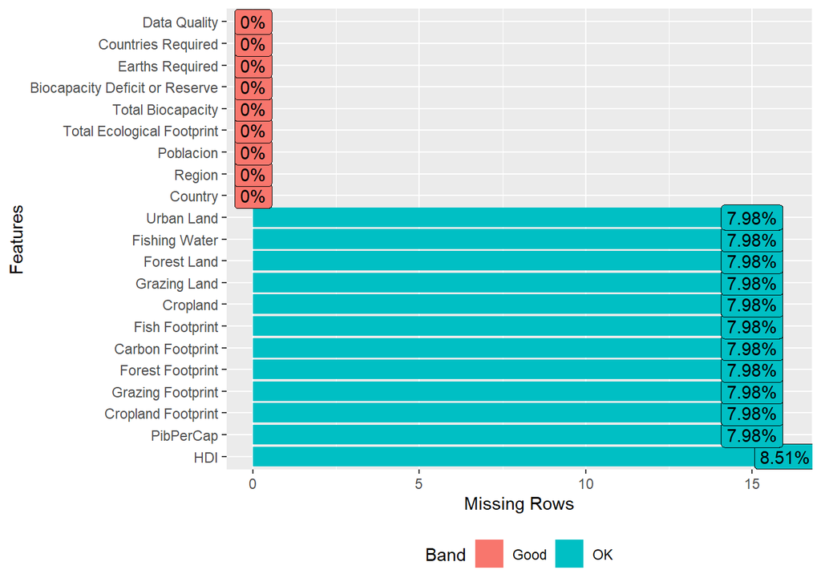

```r
plot_missing(huella_eco)
```

- Como se puede comprobar, **HDI**, tiene un 8,5% de valores nulos, que será necesario tratar. En cuanto a los demas datos, podriamos igualar a 0 dichos valores, o incluso sacar una media en comparación con su Huella Ecologica Total. Quizás a través de calculo de media de una variable respecto a la otra de manera independiente. Sin embargo para lo que nos atañe en este estudio no será necesario. Las métricas que miden la huella de manera individual y la capacidad productiva de la tierra, ya se incluyen en los indices total de Huella Ecólogica Total, Biocapacidad, Tierras requeridas y Deficit de la Biocapacidad.
- Procedemos a evaluar la cantidad de nulos y la posición donde se encuentran, para saber a que paises pertenecen dichos valores inexistentes, y poder aproximar la mejor manera de tratarlos.

```r
which(is.na(huella_eco$HDI))
```

```
##  [1]   8  19  25  34  44  63  64  72  92 109 116 121 124 140 157 185
```

- En total hay 16 valores nulos en la variable HDI, a los que podemos acceder, para saber que paises no cuentan con valor para el Índice de Desarrollo Humano, nuestra variable de interés.

```r
huella_eco[c(8,19,25,34,44,63,64,72,92,109,116,121,124,140,157,185),]
```

| Country | Region | Poblacion | HDI | PibPerCap | Cropland Footprint | Grazing Footprint | Forest Footprint | Carbon Footprint | Fish Footprint | Total Ecological Footprint | Cropland | Grazing Land | Forest Land | Fishing Water | Urban Land | Total Biocapacity | Biocapacity Deficit or Reserve | Earths Required | Countries Required | Data Quality |
| --- | --- | --- | --- | --- | --- | --- | --- | --- | --- | --- | --- | --- | --- | --- | --- | --- | --- | --- | --- | --- |
| Aruba | Latin America | 0.10 | NA | NA | NA | NA | NA | NA | NA | 11.88 | NA | NA | NA | NA | NA | 0.57 | -11.31 | 6.86 | 20.69 | 2 |
| Bermuda | North America | 0.06 | NA | $70,626.30 | NA | NA | NA | NA | NA | 5.77 | NA | NA | NA | NA | NA | 0.13 | -5.64 | 3.33 | 44.05 | 3T |
| British Virgin Islands | Latin America | 0.03 | NA | NA | NA | NA | NA | NA | NA | 2.86 | NA | NA | NA | NA | NA | 2.05 | -0.81 | 1.65 | 1.40 | 3T |
| Cayman Islands | Latin America | 0.06 | NA | NA | 0.36 | 0.45 | 1.23 | 3.56 | 0.05 | 5.65 | 0.00 | 0.02 | 0.19 | 0.11 | 0.00 | 0.32 | -5.33 | 3.26 | 17.91 | 3L |
| Côte d'Ivoire | Africa | 19.84 | NA | $1,016.83 | 0.51 | 0.06 | 0.22 | 0.26 | 0.14 | 1.27 | 0.88 | 0.30 | 0.48 | 0.04 | 0.08 | 1.78 | 0.51 | 0.74 | 0.72 | 6 |
| French Guiana | Latin America | 0.24 | NA | NA | 0.07 | 0.06 | 0.46 | 1.58 | 0.17 | 2.34 | 0.07 | 0.06 | 95.16 | 16.07 | 0.00 | 111.35 | 109.01 | 1.35 | 0.02 | 3L |
| French Polynesia | Asia-Pacific | 0.27 | NA | NA | 0.75 | 0.65 | 0.12 | 2.39 | 0.82 | 4.73 | 0.19 | 0.03 | 0.73 | 0.42 | 0.00 | 1.37 | -3.36 | 2.73 | 3.45 | 5 |
| Guadeloupe | Latin America | 0.46 | NA | NA | 0.11 | 0.03 | 0.16 | 2.61 | 0.31 | 3.23 | 0.11 | 0.03 | 0.13 | 0.18 | 0.00 | 0.45 | -2.77 | 1.86 | 7.14 | 5 |
| Korea, Democratic People's Republic of | Asia-Pacific | 24.76 | NA | NA | 0.28 | 0.00 | 0.14 | 0.68 | 0.02 | 1.17 | 0.24 | 0.00 | 0.21 | 0.09 | 0.06 | 0.60 | -0.57 | 0.67 | 1.94 | 6 |
| Martinique | Latin America | 0.40 | NA | NA | 0.13 | 0.02 | 0.12 | 1.73 | 0.04 | 2.08 | 0.13 | 0.02 | 0.10 | 0.09 | 0.04 | 0.39 | -1.70 | 1.20 | 5.41 | 3B |

[output cut: 6 more lines]

- Eliminaremos los paises que contienen valores nulos para el Indice de Desarrollo Humano, que por otro lado son en un su mayoria islas de pequeño tamaño, donde seguramente las mediciones se recojan en paises como Francia, o Inglaterra si se tratan de territorios de ultra mar. Las excepciones serian, Corea del Norte, Costa de Marfil y Somalia, territorios de envergadura por extension y actividad, a las que habría que inferirles los datos que hallemos en este estudio. Mencionar que esto eliminará valores de otras variables en el Data Set, pero como nos interesa comparar y comprobar como se comportan dichas variables respecto a este indice, y la relacion entre ellas, se procede a la eliminación. En cualquier caso es posible que hubiera sido mejor sustituir estos valores por cero, o por medias. Tras hecho un estudio previo de que Indice de Desarrollo Humano tienen estos paises en años donde se haya medido dicho valor, sin embargo, a fecha de hoy, siguen sin existir mediciones para estos paises.

```r
idh = huella_eco[!is.na(huella_eco$HDI),]
idh
```

| Country | Region | Poblacion | HDI | PibPerCap | Cropland Footprint | Grazing Footprint | Forest Footprint | Carbon Footprint | Fish Footprint | Total Ecological Footprint | Cropland | Grazing Land | Forest Land | Fishing Water | Urban Land | Total Biocapacity | Biocapacity Deficit or Reserve | Earths Required | Countries Required | Data Quality |
| --- | --- | --- | --- | --- | --- | --- | --- | --- | --- | --- | --- | --- | --- | --- | --- | --- | --- | --- | --- | --- |
| Afghanistan | Middle East/Central Asia | 29.820 | 0.460000 | $614.66 | 0.30 | 0.20 | 0.08 | 0.18 | 0.00 | 0.79 | 0.24 | 0.20 | 0.02 | 0.00 | 0.04 | 0.50 | -0.30 | 0.46 | 1.60000 | 6 |
| Albania | Northern/Eastern Europe | 3.160 | 0.730000 | $4,534.37 | 0.78 | 0.22 | 0.25 | 0.87 | 0.02 | 2.21 | 0.55 | 0.21 | 0.29 | 0.07 | 0.06 | 1.18 | -1.03 | 1.27 | 1.87000 | 6 |
| Algeria | Africa | 38.480 | 0.730000 | $5,430.57 | 0.60 | 0.16 | 0.17 | 1.14 | 0.01 | 2.12 | 0.24 | 0.27 | 0.03 | 0.01 | 0.03 | 0.59 | -1.53 | 1.22 | 3.61000 | 5 |
| Angola | Africa | 20.820 | 0.520000 | $4,665.91 | 0.33 | 0.15 | 0.12 | 0.20 | 0.09 | 0.93 | 0.20 | 1.42 | 0.64 | 0.26 | 0.04 | 2.55 | 1.61 | 0.54 | 0.37000 | 6 |
| Antigua and Barbuda | Latin America | 0.090 | 0.780000 | $13,205.10 | NA | NA | NA | NA | NA | 5.38 | NA | NA | NA | NA | NA | 0.94 | -4.44 | 3.11 | 5.70000 | 2 |
| Argentina | Latin America | 41.090 | 0.830000 | $13,540.00 | 0.78 | 0.79 | 0.29 | 1.08 | 0.10 | 3.14 | 2.64 | 1.86 | 0.66 | 1.67 | 0.10 | 6.92 | 3.78 | 1.82 | 0.45000 | 6 |
| Armenia | Middle East/Central Asia | 2.970 | 0.730000 | $3,426.39 | 0.74 | 0.18 | 0.34 | 0.89 | 0.01 | 2.23 | 0.44 | 0.26 | 0.10 | 0.02 | 0.07 | 0.89 | -1.35 | 1.29 | 2.52000 | 3B |
| Australia | Asia-Pacific | 23.050 | 0.930000 | $66,604.20 | 2.68 | 0.63 | 0.89 | 4.85 | 0.11 | 9.31 | 5.42 | 5.81 | 2.01 | 3.19 | 0.14 | 16.57 | 7.26 | 5.37 | 0.56000 | 5 |
| Austria | European Union | 8.460 | 0.880000 | $51,274.10 | 0.82 | 0.27 | 0.63 | 4.14 | 0.06 | 6.06 | 0.71 | 0.16 | 2.04 | 0.00 | 0.15 | 3.07 | -3.00 | 3.50 | 1.98000 | 5 |
| Azerbaijan | Middle East/Central Asia | 9.310 | 0.750000 | $7,106.04 | 0.66 | 0.22 | 0.11 | 1.25 | 0.01 | 2.31 | 0.46 | 0.20 | 0.11 | 0.02 | 0.06 | 0.85 | -1.46 | 1.33 | 2.72000 | 6 |

[output cut: 162 more lines]

```r
dim(idh)
```

```
## [1] 172  21
```

- En el caso del PibPerCap, tras la eliminación de los valores nulos del HDI, el único valor vacio pertenece al Pib de la Republica Arabiga de Siria, que hemos tomado de fuentes externas. En este caso son 709 dolares.

```r
idh$PibPerCap[is.na(idh$PibPerCap)] <- "$709.00"
idh
```

| Country | Region | Poblacion | HDI | PibPerCap | Cropland Footprint | Grazing Footprint | Forest Footprint | Carbon Footprint | Fish Footprint | Total Ecological Footprint | Cropland | Grazing Land | Forest Land | Fishing Water | Urban Land | Total Biocapacity | Biocapacity Deficit or Reserve | Earths Required | Countries Required | Data Quality |
| --- | --- | --- | --- | --- | --- | --- | --- | --- | --- | --- | --- | --- | --- | --- | --- | --- | --- | --- | --- | --- |
| Afghanistan | Middle East/Central Asia | 29.820 | 0.460000 | $614.66 | 0.30 | 0.20 | 0.08 | 0.18 | 0.00 | 0.79 | 0.24 | 0.20 | 0.02 | 0.00 | 0.04 | 0.50 | -0.30 | 0.46 | 1.60000 | 6 |
| Albania | Northern/Eastern Europe | 3.160 | 0.730000 | $4,534.37 | 0.78 | 0.22 | 0.25 | 0.87 | 0.02 | 2.21 | 0.55 | 0.21 | 0.29 | 0.07 | 0.06 | 1.18 | -1.03 | 1.27 | 1.87000 | 6 |
| Algeria | Africa | 38.480 | 0.730000 | $5,430.57 | 0.60 | 0.16 | 0.17 | 1.14 | 0.01 | 2.12 | 0.24 | 0.27 | 0.03 | 0.01 | 0.03 | 0.59 | -1.53 | 1.22 | 3.61000 | 5 |
| Angola | Africa | 20.820 | 0.520000 | $4,665.91 | 0.33 | 0.15 | 0.12 | 0.20 | 0.09 | 0.93 | 0.20 | 1.42 | 0.64 | 0.26 | 0.04 | 2.55 | 1.61 | 0.54 | 0.37000 | 6 |
| Antigua and Barbuda | Latin America | 0.090 | 0.780000 | $13,205.10 | NA | NA | NA | NA | NA | 5.38 | NA | NA | NA | NA | NA | 0.94 | -4.44 | 3.11 | 5.70000 | 2 |
| Argentina | Latin America | 41.090 | 0.830000 | $13,540.00 | 0.78 | 0.79 | 0.29 | 1.08 | 0.10 | 3.14 | 2.64 | 1.86 | 0.66 | 1.67 | 0.10 | 6.92 | 3.78 | 1.82 | 0.45000 | 6 |
| Armenia | Middle East/Central Asia | 2.970 | 0.730000 | $3,426.39 | 0.74 | 0.18 | 0.34 | 0.89 | 0.01 | 2.23 | 0.44 | 0.26 | 0.10 | 0.02 | 0.07 | 0.89 | -1.35 | 1.29 | 2.52000 | 3B |
| Australia | Asia-Pacific | 23.050 | 0.930000 | $66,604.20 | 2.68 | 0.63 | 0.89 | 4.85 | 0.11 | 9.31 | 5.42 | 5.81 | 2.01 | 3.19 | 0.14 | 16.57 | 7.26 | 5.37 | 0.56000 | 5 |
| Austria | European Union | 8.460 | 0.880000 | $51,274.10 | 0.82 | 0.27 | 0.63 | 4.14 | 0.06 | 6.06 | 0.71 | 0.16 | 2.04 | 0.00 | 0.15 | 3.07 | -3.00 | 3.50 | 1.98000 | 5 |
| Azerbaijan | Middle East/Central Asia | 9.310 | 0.750000 | $7,106.04 | 0.66 | 0.22 | 0.11 | 1.25 | 0.01 | 2.31 | 0.46 | 0.20 | 0.11 | 0.02 | 0.06 | 0.85 | -1.46 | 1.33 | 2.72000 | 6 |

[output cut: 162 more lines]

- Para poder transformar la variable a númerica, el primer tratamiento que habra que darle es eliminar el dolar al comienzo de cada linea de datos. Despeus tendremos problemas con la coma, por lo que habrá que cambiarla por un punto.

```r
PibPerCap_ <- sub("[$]", "", idh$PibPerCap)
PibPerCap_
```

```
##   [1] "614.66"     "4,534.37"   "5,430.57"   "4,665.91"   "13,205.10"
##   [6] "13,540.00"  "3,426.39"   "66,604.20"  "51,274.10"  "7,106.04"
##  [11] "22,647.30"  "24,299.00"  "857.50"     "15,722.80"  "6,300.45"
##  [16] "48,053.30"  "746.83"     "2,395.00"   "2,253.09"   "4,708.85"
##  [21] "7,743.50"   "13,237.60"  "47,097.40"  "7,615.28"   "671.07"
##  [26] "276.69"     "3,801.45"   "877.64"     "1,271.21"   "52,145.40"
##  [31] "495.04"     "1,161.22"   "14,525.80"  "5,560.94"   "7,305.22"
##  [36] "860.24"     "1,943.69"   "338.63"     "8,979.96"   "14,522.80"
##  [41] "5,175.94"   "31,454.70"  "21,676.30"  "61,413.60"  "1,433.17"
##  [46] "7,088.01"   "6,085.89"   "5,192.88"   "2,930.33"   "3,696.33"
##  [51] "24,064.00"  "439.73"     "17,304.40"  "379.38"     "4,201.37"
##  [56] "50,960.20"  "45,430.30"  "11,989.00"  "505.76"     "3,710.70"
##  [61] "46,822.40"  "1,627.90"   "25,987.40"  "7,410.48"   "3,233.80"
##  [66] "459.09"     "681.25"     "3,269.46"   "749.13"     "2,269.51"
##  [71] "13,964.20"  "1,513.85"   "3,688.53"   "7,511.10"   "5,848.54"
```

[output cut: 20 more lines]

```r
PibPerCap_ <- sub("[,]", "", PibPerCap_)
PibPerCap_
```

```
##   [1] "614.66"    "4534.37"   "5430.57"   "4665.91"   "13205.10"  "13540.00"
##   [7] "3426.39"   "66604.20"  "51274.10"  "7106.04"   "22647.30"  "24299.00"
##  [13] "857.50"    "15722.80"  "6300.45"   "48053.30"  "746.83"    "2395.00"
##  [19] "2253.09"   "4708.85"   "7743.50"   "13237.60"  "47097.40"  "7615.28"
##  [25] "671.07"    "276.69"    "3801.45"   "877.64"    "1271.21"   "52145.40"
##  [31] "495.04"    "1161.22"   "14525.80"  "5560.94"   "7305.22"   "860.24"
##  [37] "1943.69"   "338.63"    "8979.96"   "14522.80"  "5175.94"   "31454.70"
##  [43] "21676.30"  "61413.60"  "1433.17"   "7088.01"   "6085.89"   "5192.88"
##  [49] "2930.33"   "3696.33"   "24064.00"  "439.73"    "17304.40"  "379.38"
##  [55] "4201.37"   "50960.20"  "45430.30"  "11989.00"  "505.76"    "3710.70"
##  [61] "46822.40"  "1627.90"   "25987.40"  "7410.48"   "3233.80"   "459.09"
##  [67] "681.25"    "3269.46"   "749.13"    "2269.51"   "13964.20"  "1513.85"
##  [73] "3688.53"   "7511.10"   "5848.54"   "52853.60"  "33718.90"  "38412.00"
##  [79] "5226.30"   "46201.60"  "4615.17"   "11278.00"  "1062.11"   "24155.80"
##  [85] "41830.50"  "1116.37"   "1236.24"   "13732.00"  "9143.86"   "1338.42"
##  [91] "397.38"    "5859.43"   "14373.70"  "114665.00" "5174.89"   "456.33"
##  [97] "493.84"    "10252.60"  "741.22"    "1524.39"   "8811.15"   "10123.90"
## [103] "1971.03"   "3736.07"   "7251.60"   "3149.43"   "538.82"    "1117.58"
## [109] "5880.80"   "700.07"    "53589.90"  "37488.30"  "1626.85"   "410.91"
## [115] "2612.12"   "100172.00" "22622.80"  "1218.60"   "8410.77"   "1871.21"
## [121] "3557.31"   "5684.73"   "2379.44"   "13769.50"  "23217.30"  "99431.50"
## [127] "9213.94"   "13320.20"  "628.08"    "12952.50"  "7737.20"   "6171.48"
## [133] "4067.15"   "1384.53"   "23593.80"  "1079.27"   "6426.18"   "499.89"
## [139] "53122.40"  "18103.10"  "25040.50"  "1647.86"   "8089.87"   "32008.70"
## [145] "2880.03"   "8190.70"   "4657.48"   "59381.90"  "88506.20"  "709.00"
## [151] "836.17"    "765.33"    "5479.29"   "5167.86"   "580.86"    "4330.90"
## [157] "18310.80"  "4305.07"   "10437.70"  "5290.14"   "601.35"    "3589.63"
## [163] "40980.50"  "40817.40"  "49725.00"  "14238.10"  "1560.85"   "10237.80"
## [169] "1532.31"   "1302.30"   "1740.64"   "865.91"
```

- Desde aquí se puede cambiar el valor del Pib per Capita a númerico, y trabajar con ello. Se añade al data frame.

```r
PibPerCap_ <- as.numeric(PibPerCap_)
```

- Se elimina la columna antigua con los datos de PIB, para añadir la nueva transformada.

```r
idh <- idh[-5]
idh <- cbind(idh, PibPerCap_)
```

```r
head(idh)
```

|  | Country | Region | Poblacion | HDI | Cropland Footprint | Grazing Footprint | Forest Footprint | Carbon Footprint | Fish Footprint | Total Ecological Footprint | Cropland | Grazing Land | Forest Land | Fishing Water | Urban Land | Total Biocapacity | Biocapacity Deficit or Reserve | Earths Required | Countries Required | Data Quality | PibPerCap_ |
| --- | --- | --- | --- | --- | --- | --- | --- | --- | --- | --- | --- | --- | --- | --- | --- | --- | --- | --- | --- | --- | --- |
| 1 | Afghanistan | Middle East/Central Asia | 29.82 | 0.46 | 0.30 | 0.20 | 0.08 | 0.18 | 0.00 | 0.79 | 0.24 | 0.20 | 0.02 | 0.00 | 0.04 | 0.50 | -0.30 | 0.46 | 1.60 | 6 | 614.66 |
| 2 | Albania | Northern/Eastern Europe | 3.16 | 0.73 | 0.78 | 0.22 | 0.25 | 0.87 | 0.02 | 2.21 | 0.55 | 0.21 | 0.29 | 0.07 | 0.06 | 1.18 | -1.03 | 1.27 | 1.87 | 6 | 4534.37 |
| 3 | Algeria | Africa | 38.48 | 0.73 | 0.60 | 0.16 | 0.17 | 1.14 | 0.01 | 2.12 | 0.24 | 0.27 | 0.03 | 0.01 | 0.03 | 0.59 | -1.53 | 1.22 | 3.61 | 5 | 5430.57 |
| 4 | Angola | Africa | 20.82 | 0.52 | 0.33 | 0.15 | 0.12 | 0.20 | 0.09 | 0.93 | 0.20 | 1.42 | 0.64 | 0.26 | 0.04 | 2.55 | 1.61 | 0.54 | 0.37 | 6 | 4665.91 |
| 5 | Antigua and Barbuda | Latin America | 0.09 | 0.78 | NA | NA | NA | NA | NA | 5.38 | NA | NA | NA | NA | NA | 0.94 | -4.44 | 3.11 | 5.70 | 2 | 13205.10 |
| 6 | Argentina | Latin America | 41.09 | 0.83 | 0.78 | 0.79 | 0.29 | 1.08 | 0.10 | 3.14 | 2.64 | 1.86 | 0.66 | 1.67 | 0.10 | 6.92 | 3.78 | 1.82 | 0.45 | 6 | 13540.00 |

- Atendiendo a la estructura de nuestra variable de interés se proceder a categorizarla. La intención es buscar que nos facilite el análisis de la misma. De este manera se tranforma dicha variable a categorica ordinal siguiendo los estandares definidos en el apartado 1. Finalmente se añade al dataframe, con el nombre de HDI_CAT

```r
HDI_CAT = cut(idh$HDI, breaks = c(0,0.55,0.70,0.80, 1), labels = c("Bajo", "Medio", "Alto", "Muy Alto"), include.lowest = TRUE)
HDI_CAT
```

```
##   [1] Bajo     Alto     Alto     Bajo     Alto     Muy Alto Alto     Muy Alto
##   [9] Muy Alto Alto     Alto     Muy Alto Medio    Alto     Alto     Muy Alto
##  [17] Bajo     Medio    Medio    Alto     Medio    Alto     Muy Alto Alto
##  [25] Bajo     Bajo     Medio    Bajo     Bajo     Muy Alto Bajo     Bajo
##  [33] Muy Alto Alto     Alto     Bajo     Medio    Bajo     Alto     Muy Alto
##  [41] Alto     Muy Alto Muy Alto Muy Alto Bajo     Alto     Alto     Alto
##  [49] Medio    Medio    Medio    Bajo     Muy Alto Bajo     Alto     Muy Alto
##  [57] Muy Alto Medio    Bajo     Alto     Muy Alto Medio    Muy Alto Alto
##  [65] Medio    Bajo     Bajo     Medio    Bajo     Medio    Muy Alto Medio
##  [73] Medio    Alto     Medio    Muy Alto Muy Alto Muy Alto Alto     Muy Alto
##  [81] Alto     Alto     Bajo     Muy Alto Muy Alto Medio    Medio    Muy Alto
##  [89] Alto     Bajo     Bajo     Alto     Muy Alto Muy Alto Alto     Bajo
##  [97] Bajo     Alto     Bajo     Bajo     Alto     Alto     Medio    Alto
## [105] Alto     Medio    Bajo     Bajo     Medio    Bajo     Muy Alto Muy Alto
## [113] Medio    Bajo     Bajo     Muy Alto Alto     Bajo     Alto     Bajo
## [121] Medio    Alto     Medio    Muy Alto Muy Alto Muy Alto Alto     Alto
## [129] Bajo     Alto     Alto     Alto     Medio    Bajo     Muy Alto Bajo
## [137] Alto     Bajo     Muy Alto Muy Alto Muy Alto Bajo     Medio    Muy Alto
## [145] Alto     Alto     Bajo     Muy Alto Muy Alto Medio    Medio    Bajo
## [153] Alto     Medio    Bajo     Alto     Alto     Alto     Alto     Medio
## [161] Bajo     Alto     Muy Alto Muy Alto Muy Alto Alto     Medio    Alto
## [169] Medio    Bajo     Medio    Bajo
## Levels: Bajo Medio Alto Muy Alto
```

```r
idh = cbind(idh, HDI_CAT)
```

- Comprobamos que hemos añadido la nueva variable categorizada.

```r
head(idh,10)
```

|  | Country | Region | Poblacion | HDI | Cropland Footprint | Grazing Footprint | Forest Footprint | Carbon Footprint | Fish Footprint | Total Ecological Footprint | Cropland | Grazing Land | Forest Land | Fishing Water | Urban Land | Total Biocapacity | Biocapacity Deficit or Reserve | Earths Required | Countries Required | Data Quality | PibPerCap_ | HDI_CAT |
| --- | --- | --- | --- | --- | --- | --- | --- | --- | --- | --- | --- | --- | --- | --- | --- | --- | --- | --- | --- | --- | --- | --- |
| 1 | Afghanistan | Middle East/Central Asia | 29.82 | 0.46 | 0.30 | 0.20 | 0.08 | 0.18 | 0.00 | 0.79 | 0.24 | 0.20 | 0.02 | 0.00 | 0.04 | 0.50 | -0.30 | 0.46 | 1.60 | 6 | 614.66 | Bajo |
| 2 | Albania | Northern/Eastern Europe | 3.16 | 0.73 | 0.78 | 0.22 | 0.25 | 0.87 | 0.02 | 2.21 | 0.55 | 0.21 | 0.29 | 0.07 | 0.06 | 1.18 | -1.03 | 1.27 | 1.87 | 6 | 4534.37 | Alto |
| 3 | Algeria | Africa | 38.48 | 0.73 | 0.60 | 0.16 | 0.17 | 1.14 | 0.01 | 2.12 | 0.24 | 0.27 | 0.03 | 0.01 | 0.03 | 0.59 | -1.53 | 1.22 | 3.61 | 5 | 5430.57 | Alto |
| 4 | Angola | Africa | 20.82 | 0.52 | 0.33 | 0.15 | 0.12 | 0.20 | 0.09 | 0.93 | 0.20 | 1.42 | 0.64 | 0.26 | 0.04 | 2.55 | 1.61 | 0.54 | 0.37 | 6 | 4665.91 | Bajo |
| 5 | Antigua and Barbuda | Latin America | 0.09 | 0.78 | NA | NA | NA | NA | NA | 5.38 | NA | NA | NA | NA | NA | 0.94 | -4.44 | 3.11 | 5.70 | 2 | 13205.10 | Alto |
| 6 | Argentina | Latin America | 41.09 | 0.83 | 0.78 | 0.79 | 0.29 | 1.08 | 0.10 | 3.14 | 2.64 | 1.86 | 0.66 | 1.67 | 0.10 | 6.92 | 3.78 | 1.82 | 0.45 | 6 | 13540.00 | Muy Alto |
| 7 | Armenia | Middle East/Central Asia | 2.97 | 0.73 | 0.74 | 0.18 | 0.34 | 0.89 | 0.01 | 2.23 | 0.44 | 0.26 | 0.10 | 0.02 | 0.07 | 0.89 | -1.35 | 1.29 | 2.52 | 3B | 3426.39 | Alto |
| 8 | Australia | Asia-Pacific | 23.05 | 0.93 | 2.68 | 0.63 | 0.89 | 4.85 | 0.11 | 9.31 | 5.42 | 5.81 | 2.01 | 3.19 | 0.14 | 16.57 | 7.26 | 5.37 | 0.56 | 5 | 66604.20 | Muy Alto |
| 9 | Austria | European Union | 8.46 | 0.88 | 0.82 | 0.27 | 0.63 | 4.14 | 0.06 | 6.06 | 0.71 | 0.16 | 2.04 | 0.00 | 0.15 | 3.07 | -3.00 | 3.50 | 1.98 | 5 | 51274.10 | Muy Alto |
| 10 | Azerbaijan | Middle East/Central Asia | 9.31 | 0.75 | 0.66 | 0.22 | 0.11 | 1.25 | 0.01 | 2.31 | 0.46 | 0.20 | 0.11 | 0.02 | 0.06 | 0.85 | -1.46 | 1.33 | 2.72 | 6 | 7106.04 | Alto |

```r
summary(idh)
```

```
##    Country             Region            Poblacion             HDI
##  Length:172         Length:172         Min.   :   0.050   Min.   :0.3400
##  Class :character   Class :character   1st Qu.:   3.015   1st Qu.:0.5575
##  Mode  :character   Mode  :character   Median :   9.355   Median :0.7200
##                                        Mean   :  40.481   Mean   :0.6864
##                                        3rd Qu.:  28.352   3rd Qu.:0.8025
##                                        Max.   :1408.040   Max.   :0.9400
##
##  Cropland Footprint Grazing Footprint Forest Footprint Carbon Footprint
##  Min.   :0.1000     Min.   :0.000     Min.   :0.0100   Min.   : 0.000
##  1st Qu.:0.3550     1st Qu.:0.090     1st Qu.:0.1700   1st Qu.: 0.400
##  Median :0.5200     Median :0.180     Median :0.2700   Median : 1.090
##  Mean   :0.5941     Mean   :0.265     Mean   :0.3765   Mean   : 1.806
##  3rd Qu.:0.7150     3rd Qu.:0.310     3rd Qu.:0.4600   3rd Qu.: 2.590
##  Max.   :2.6800     Max.   :3.470     Max.   :3.0300   Max.   :12.650
##  NA's   :9          NA's   :9         NA's   :9        NA's   :9
##  Fish Footprint   Total Ecological Footprint    Cropland       Grazing Land
##  Min.   :0.0000   Min.   : 0.420             Min.   :0.0000   Min.   :0.0000
##  1st Qu.:0.0200   1st Qu.: 1.452             1st Qu.:0.2050   1st Qu.:0.0400
##  Median :0.0700   Median : 2.700             Median :0.3600   Median :0.1200
##  Mean   :0.1179   Mean   : 3.264             Mean   :0.5527   Mean   :0.4764
##  3rd Qu.:0.1400   3rd Qu.: 4.513             3rd Qu.:0.5950   3rd Qu.:0.3400
##  Max.   :0.8100   Max.   :15.820             Max.   :5.4200   Max.   :8.2300
##  NA's   :9                                   NA's   :9        NA's   :9
##   Forest Land     Fishing Water      Urban Land      Total Biocapacity
##  Min.   : 0.000   Min.   :0.0000   Min.   :0.00000   Min.   : 0.050
##  1st Qu.: 0.060   1st Qu.:0.0250   1st Qu.:0.04000   1st Qu.: 0.710
##  Median : 0.340   Median :0.1100   Median :0.05000   Median : 1.335
##  Mean   : 2.001   Mean   :0.4925   Mean   :0.06975   Mean   : 3.631
##  3rd Qu.: 1.175   3rd Qu.:0.3600   3rd Qu.:0.09000   3rd Qu.: 2.888
##  Max.   :81.520   Max.   :8.2700   Max.   :0.27000   Max.   :89.330
##  NA's   :9        NA's   :9        NA's   :9
##  Biocapacity Deficit or Reserve Earths Required  Countries Required
##  Min.   :-14.1400               Min.   :0.2400   Min.   :  0.050
##  1st Qu.: -1.8350               1st Qu.:0.8375   1st Qu.:  0.915
##  Median : -0.7050               Median :1.5600   Median :  1.665
##  Mean   :  0.3666               Mean   :1.8851   Mean   :  3.557
##  3rd Qu.:  0.4025               3rd Qu.:2.6000   3rd Qu.:  2.562
##  Max.   : 85.0800               Max.   :9.1400   Max.   :159.470
##
##  Data Quality         PibPerCap_           HDI_CAT
##  Length:172         Min.   :   276.7   Bajo    :43
##  Class :character   1st Qu.:  1521.8   Medio   :34
##  Mode  :character   Median :  5360.4   Alto    :52
##                     Mean   : 13908.7   Muy Alto:43
##                     3rd Qu.: 14411.0
##                     Max.   :114665.0
##
```

- Tras analizar detenidamente de manera teorica las variables, se toma le decision de no tener en cuenta las variables relacionadas con las diferentes huellas ni tampoco con la cantidad de tierra productiva. La razón es sencillamente que al estar implicitas en los sumatorios totales, se prefieren dejar fuera del estudio.
- Podriamos hacer un select para el nuevo dataset, pero el hecho de eliminar las columnas de esta forma, deja patente cuales se eliminan y porque se eliminan. Además quitamos Data Quality, por ser una variable que no tiene ningun interés en nuestro estudio y countries required, ya que esta última ya va implicita en tierras requeridas, otra variable con la que trabajaremos.

```r
idh$`Cropland Footprint` <- NULL
idh$Cropland <- NULL
idh$`Forest Footprint` <- NULL
idh$`Grazing Footprint` <- NULL
idh$`Fish Footprint` <- NULL
idh$`Carbon Footprint` <- NULL
idh$`Grazing Land` <- NULL
idh$`Forest Land` <- NULL
idh$`Fishing Water` <- NULL
idh$`Urban Land` <- NULL
idh$`Data Quality` <- NULL
```

```r
idh$`Countries Required` <- NULL
```

```r
head(idh,10)
```

|  | Country | Region | Poblacion | HDI | Total Ecological Footprint | Total Biocapacity | Biocapacity Deficit or Reserve | Earths Required | PibPerCap_ | HDI_CAT |
| --- | --- | --- | --- | --- | --- | --- | --- | --- | --- | --- |
| 1 | Afghanistan | Middle East/Central Asia | 29.82 | 0.46 | 0.79 | 0.50 | -0.30 | 0.46 | 614.66 | Bajo |
| 2 | Albania | Northern/Eastern Europe | 3.16 | 0.73 | 2.21 | 1.18 | -1.03 | 1.27 | 4534.37 | Alto |
| 3 | Algeria | Africa | 38.48 | 0.73 | 2.12 | 0.59 | -1.53 | 1.22 | 5430.57 | Alto |
| 4 | Angola | Africa | 20.82 | 0.52 | 0.93 | 2.55 | 1.61 | 0.54 | 4665.91 | Bajo |
| 5 | Antigua and Barbuda | Latin America | 0.09 | 0.78 | 5.38 | 0.94 | -4.44 | 3.11 | 13205.10 | Alto |
| 6 | Argentina | Latin America | 41.09 | 0.83 | 3.14 | 6.92 | 3.78 | 1.82 | 13540.00 | Muy Alto |
| 7 | Armenia | Middle East/Central Asia | 2.97 | 0.73 | 2.23 | 0.89 | -1.35 | 1.29 | 3426.39 | Alto |
| 8 | Australia | Asia-Pacific | 23.05 | 0.93 | 9.31 | 16.57 | 7.26 | 5.37 | 66604.20 | Muy Alto |
| 9 | Austria | European Union | 8.46 | 0.88 | 6.06 | 3.07 | -3.00 | 3.50 | 51274.10 | Muy Alto |
| 10 | Azerbaijan | Middle East/Central Asia | 9.31 | 0.75 | 2.31 | 0.85 | -1.46 | 1.33 | 7106.04 | Alto |

- A partir de aquí, vamos a obtener la media, desviación tipica de cada variable de interés que serán necesarias para el futuro ánalisis de los datos.

```r
meanh = mean(idh$HDI)
meanh
```

```
## [1] 0.6863596
```

```r
meanf = mean(idh$`Total Ecological Footprint`)
meanf
```

```
## [1] 3.26436
```

```r
meanb = mean(idh$`Total Biocapacity`)
meanb
```

```
## [1] 3.630872
```

```r
meane = mean(idh$`Earths Required`)
meane
```

```
## [1] 1.885116
```

```r
meanp = mean(idh$Poblacion)
meanp
```

```
## [1] 40.48149
```

```r
meang = mean(idh$PibPerCap_)
meang
```

```
## [1] 13908.7
```

```r
meand = mean(idh$`Biocapacity Deficit or Reserve`)
meand
```

```
## [1] 0.3665698
```

- Llama la atención que segun los datos obtenidos, la media de HDI en el mundo esta en nivel medio, que la huella ecológica esta por encima de 3, y curiosamente al borde de la media de la biocapacidad, y que la manera de consumir del mundo atendiendo a todo esto necesitaria 1,8 planetas de media para satisfacer dicho consumo.

```r
sdh = sd(idh$HDI)
sdh
```

```
## [1] 0.1560397
```

```r
sdf = sd(idh$`Total Ecological Footprint`)
sdf
```

```
## [1] 2.327458
```

```r
sdb = sd(idh$`Total Biocapacity`)
sdb
```

```
## [1] 8.998679
```

```r
sde = sd(idh$`Earths Required`)
sde
```

```
## [1] 1.34459
```

```r
sdp = sd(idh$Poblacion)
sdp
```

```
## [1] 146.7806
```

```r
sdg = sd(idh$PibPerCap_)
sdg
```

```
## [1] 20539.12
```

```r
sdd = sd(idh$`Biocapacity Deficit or Reserve`)
sdd
```

```
## [1] 8.986271
```

**Las muestras que tenemos, son el total de la población de las cuales se tienen datos, por tanto calcular los intervalos de confianza de estadísticos como la media quizás no fuera necesario, aun asi puede hacerse**

```r
valores <- idh %>% dplyr::select("Poblacion", "HDI","Total Ecological Footprint", "Total Biocapacity", "Biocapacity Deficit or Reserve", "Earths Required", "PibPerCap_")

sapply(valores, function(x) round(t.test((x), conf.level = 0.95)$p.value,2))
```

```
##                      Poblacion                            HDI
##                           0.00                           0.00
##     Total Ecological Footprint              Total Biocapacity
##                           0.00                           0.00
## Biocapacity Deficit or Reserve                Earths Required
##                           0.59                           0.00
##                     PibPerCap_
##                           0.00
```

Visualización de variables

- Utilizando la función creada en el seminario impartido en relación al analisis exploratorio. Se ha moficado el contenido para poder hacer una visualización de cada una de aquellas variables que nos interesan para nuestro estudio.

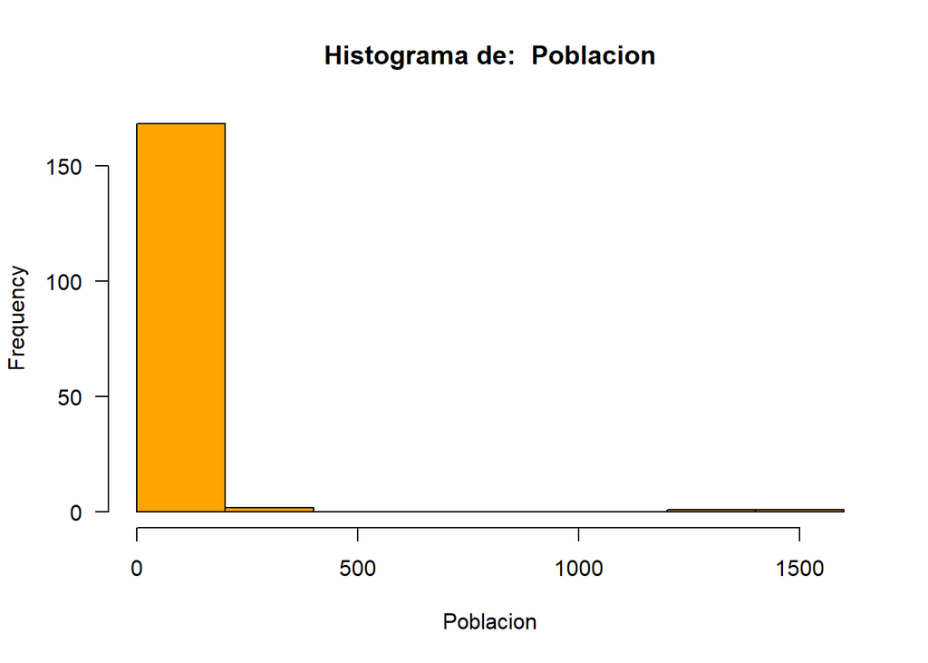

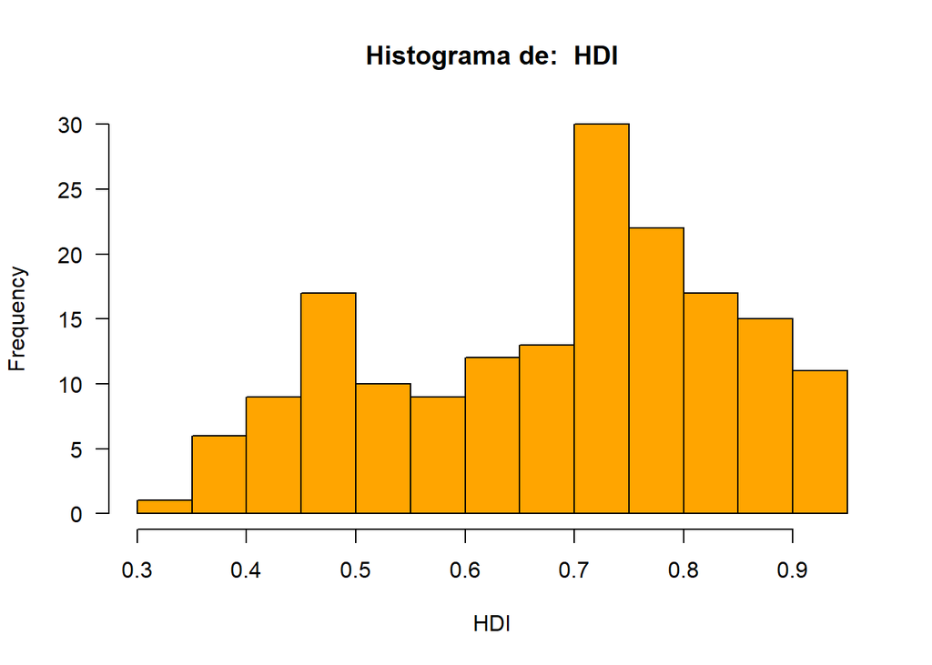

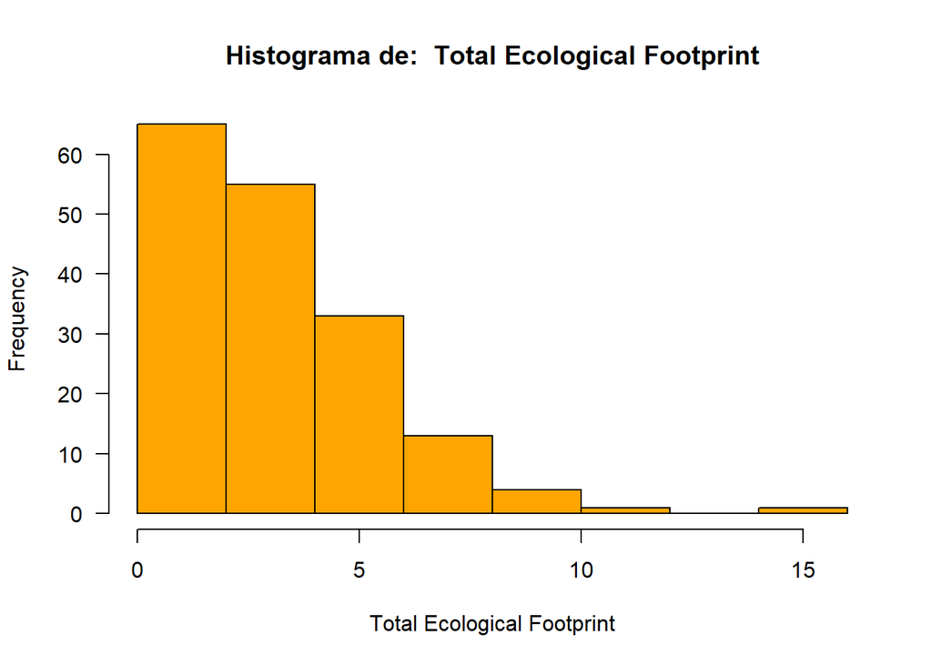

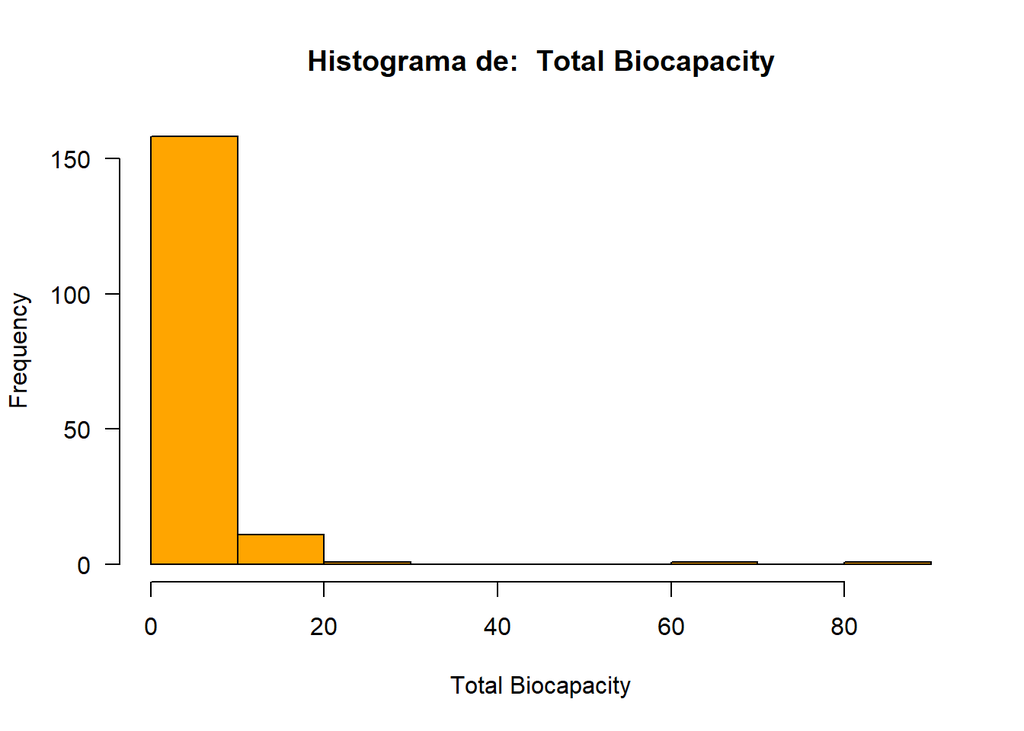

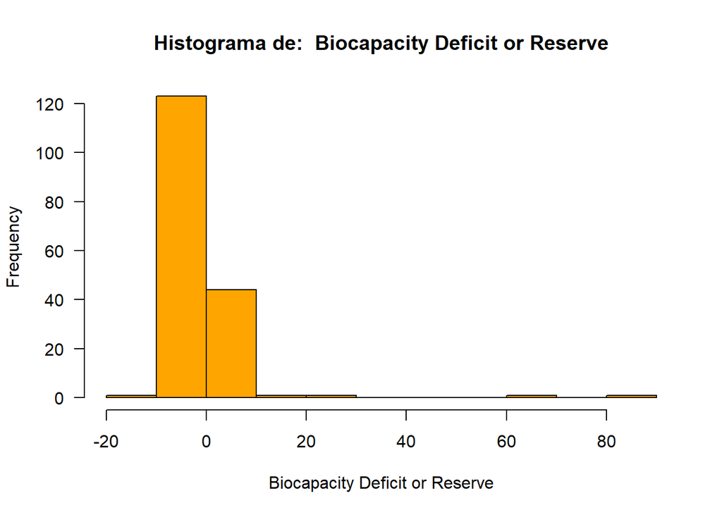

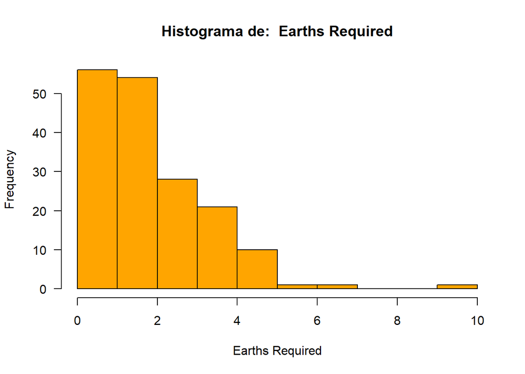

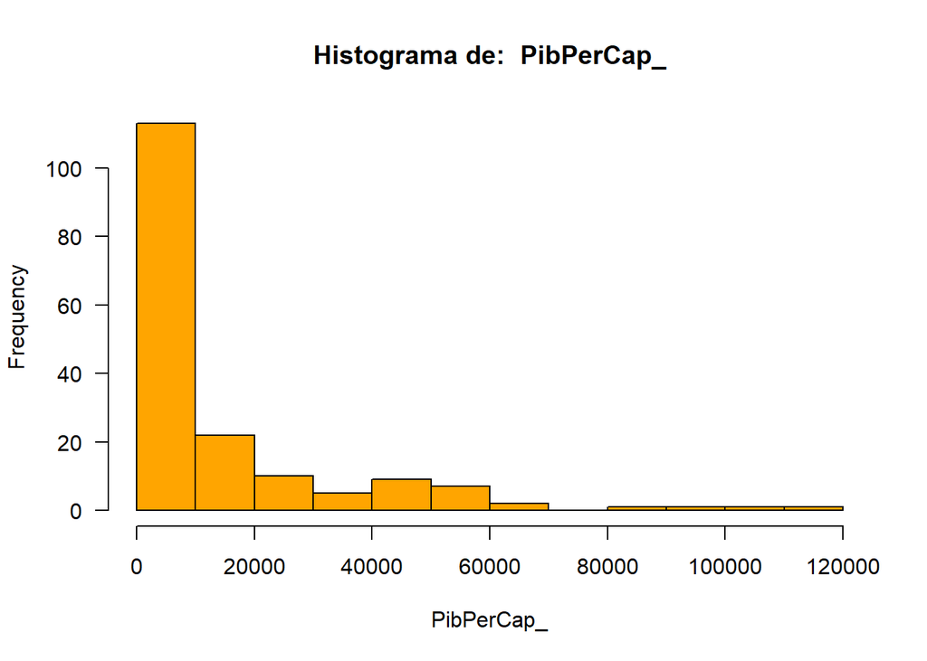

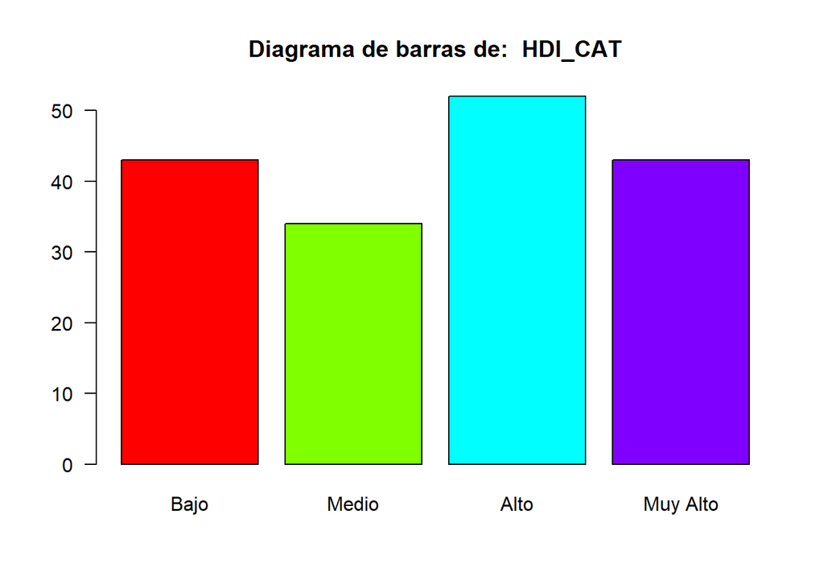

```r
for (columna in 3:ncol(idh)){
  if (class(idh[,columna]) == "factor"){
    # Por defecto se mostrará un gráfico de barras.
    plot(idh[,columna],
         col = rainbow(length(levels(idh[,columna]))),
         las = 1,
         main = paste("Diagrama de barras de: ", colnames(idh[columna])))
  } else {
    # Para las variables numéricas, histograma.
    hist(idh[, columna],
         border = "black",
         col = "orange",
         las = 1,
         main = paste("Histograma de: ", colnames(idh[columna])),
         xlab  = colnames(idh[columna]))
  }
}
```

```r
idh$Country[idh$`Biocapacity Deficit or Reserve` > 10]
```

```
## [1] "Bolivia"  "Gabon"    "Guyana"   "Suriname"
```

- Esta pequeña exploración de que paises son, nos podria aproximar que su requerimiento ecólogico esta muy por debajo de su biocapacidad. ¿Tendra que ver con su indice de desarrollo?
6. **CANTIDAD DE TIERRAS REQUERIDAS**, como se puede observar la mayoría de paises estan entre 0 y 2 tierras según su requerimiento ecológico. Aun asi no es despreciable la cifra de paises que si todo el globo consumiera como ellos, se necesitarian 4 planetas para cubrir los requerimientos.

```r
idh$Country[idh$`Earths Required` > 4]
```

```
##  [1] "Australia"                "Bahrain"
##  [3] "Belgium"                  "Canada"
##  [5] "Kuwait"                   "Luxembourg"
##  [7] "Oman"                     "Qatar"
##  [9] "Singapore"                "Sweden"
## [11] "Trinidad and Tobago"      "United Arab Emirates"
## [13] "United States of America"
```

```r
idh$Country[idh$`Earths Required` > 9]
```

```
## [1] "Luxembourg"
```

7. **HDI CATEGORIZADA**
- Vamos a utilizar nuestra variable categorica recien creada para intentar sacar alguna conclusión a partir de la visualización y de este modo interpretar si encontraremos relaciones entre las variables cuando apliquemos nuestros modelos.

```r
idh_freacum = table(idh$HDI_CAT)
idh_freacum
```

```
##
##     Bajo    Medio     Alto Muy Alto
##       43       34       52       43
```

```r
prop.table(idh_freacum)
```

```
##
##      Bajo     Medio      Alto  Muy Alto
## 0.2500000 0.1976744 0.3023256 0.2500000
```

- Como podemos ver la frecuencia absoluta nos dice que hay una distribución bastante homogenea de paises en cada rango de nivel de Indice de desarrollo humano. Es decir los paises pertenecen en proporciones parecidas a los diferentes niveles de Idh, algo que podemos comprobar con las frecuencias relativas.
- Del total de paises, el 30% de los paises tienen un IDH alto, el 25% de los paises un IDH Muy alto, el 25% de los paises un IDH bajo, y un 19,8% tienen un IDH medio. Destacar que los niveles muy alto y bajo, tienen la misma proporción de paises.

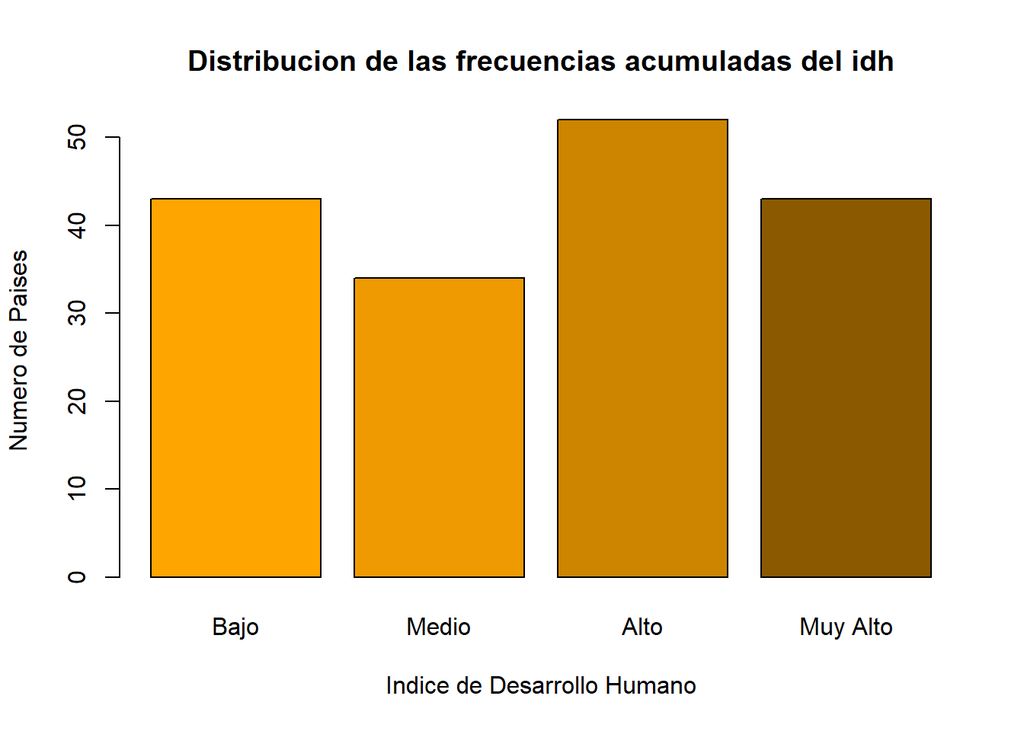

```r
barplot(idh_freacum, xlab = "Indice de Desarrollo Humano", ylab = "Numero de Paises", main = "Distribucion de las frecuencias acumuladas del idh", col = c("orange1", "orange2", "orange3", "orange4"))
```

- Si observamos este gráfico de barras, podemos ver como la mayor proporción de paises tienen índices de desarrollo humano alto. Ademas podemos decir que del total de paises algo mas de la mitad tienen valores altos o muy altos en este indice.

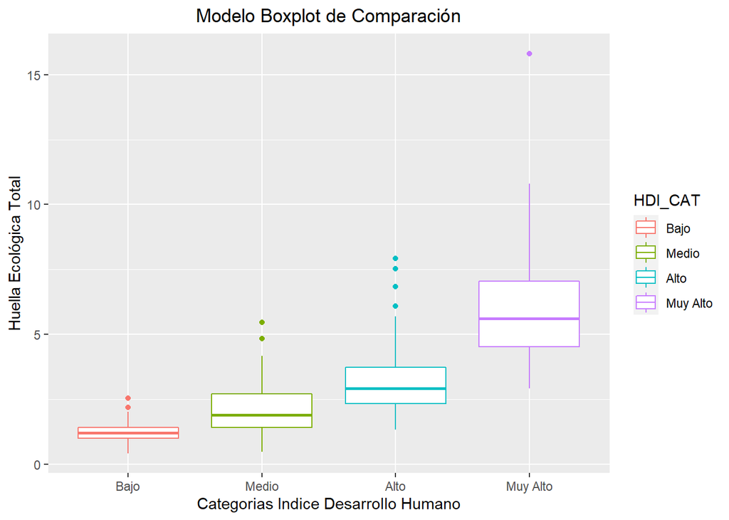

```r
ggplot(data = idh, aes(x = HDI_CAT, y = `Total Ecological Footprint`, color = HDI_CAT)) +
    geom_boxplot() +
   ggtitle("Modelo Boxplot de Comparación") +
   theme(plot.title = element_text(hjust = 0.5)) +
            labs(x = "Categorias Indice Desarrollo Humano", y = "Huella Ecológica Total")
```

- Lo primero que llama la atencion, es que los valores de huella ecólogica aumentan con los valores de Idh. Otra situacion destacable, es que el rango intercuartilico de aquellos paises que se encuentran con valores muy altos de HDI, es mucho mayor que en el resto de niveles, lo que indica mucha variabilidad para valores muy altos, lo contrario que ocurre para valores bajos, cuyos valores se concentran mucho mas proximos a la media.

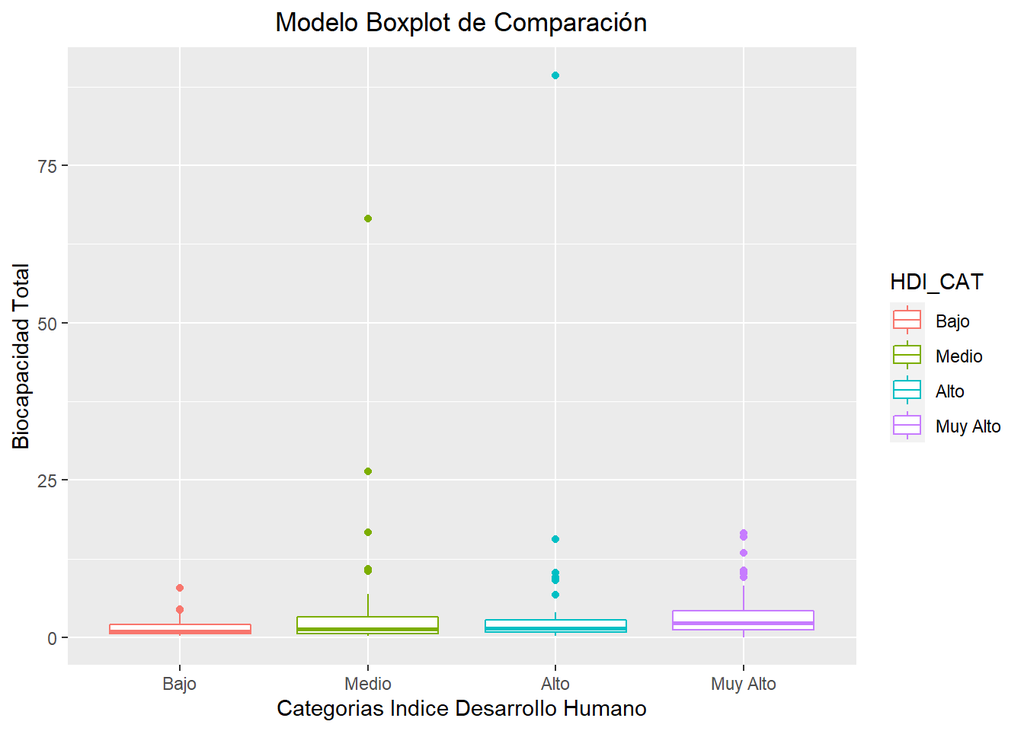

```r
ggplot(data = idh, aes(x = HDI_CAT, y = `Total Biocapacity`, color = HDI_CAT)) +
    geom_boxplot() +
   ggtitle("Modelo Boxplot de Comparación") +
   theme(plot.title = element_text(hjust = 0.5)) +
            labs(x = "Categorias Indice Desarrollo Humano", y = "Biocapacidad Total")
```

- Si se analiza este gráfico, encontramos algo llamativo. El rango intercuartilico no varía significativamente para ninguna de las categorias de indice de desarrollo humano. Por tanto, se puede decir que no hay una relacion plausible entre niveles de biocapcidad altos y indice de desarrollo humano alto o muy alto, por tanto de confirmarse que a mayor indice de desarrollo humano, mayor requerimiento ecológico, independiente de la biocapacidad, esta sería una prueba mas de que el modelo de desarrollo mundial no es el adecuado. Ya que el modelo de desarrollo actual no parece tener en cuenta una variable como la biocapacidad.

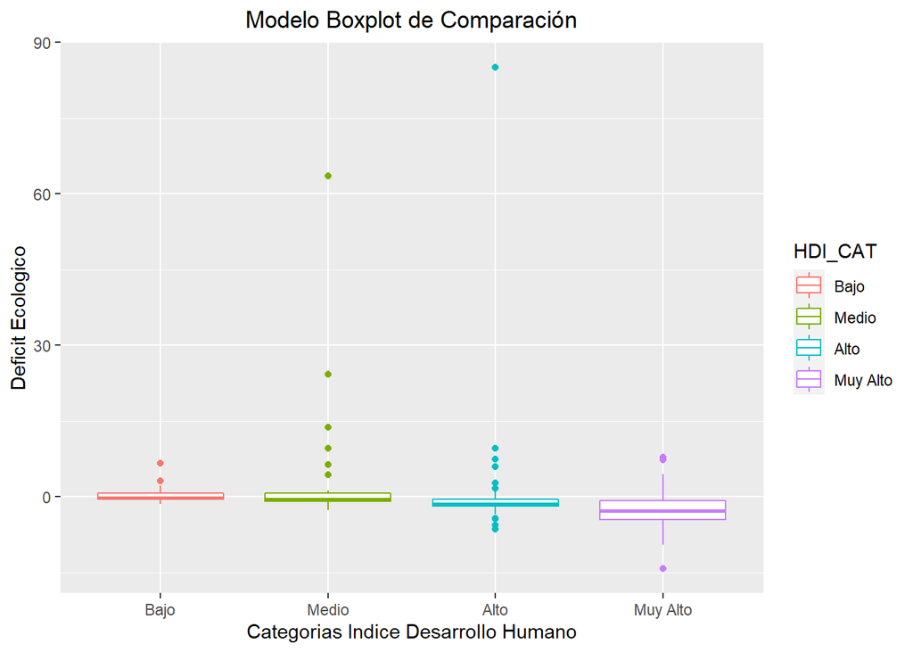

```r
ggplot(data = idh, aes(x = HDI_CAT, y = `Biocapacity Deficit or Reserve` , color = HDI_CAT)) +
    geom_boxplot() +
   ggtitle("Modelo Boxplot de Comparación") +
   theme(plot.title = element_text(hjust = 0.5)) +
            labs(x = "Categorias Indice Desarrollo Humano", y = "Deficit Ecologico")
```

- Aqui podemos encontrar una relación inversa con el nivel de desarrollo humano para esta variable. Atendiendo a su definición, parece que a mayores niveles de desarrollo, mayor es el deficit ecológico. Por eso el rango intercuartilico de los valores altos y muy altos de este índice, se encuentra por debajo del 0. Dicho de otra manera, el deficit (medio en numeros negativos, aparece para indices de desarrollo alto o muy alto, y algunos valores del medio). Por otro lado, parece ser que un índice de desarrollo bajo, tiene asociado un deficit ecológico positivo.

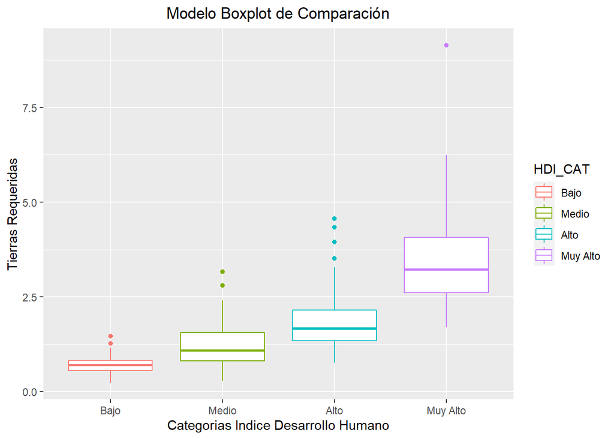

```r
ggplot(data = idh, aes(x = HDI_CAT, y = `Earths Required`, color = HDI_CAT)) +
    geom_boxplot() +
   ggtitle("Modelo Boxplot de Comparación") +
   theme(plot.title = element_text(hjust = 0.5)) +
            labs(x = "Categorias Indice Desarrollo Humano", y = "Tierras Requeridas")
```

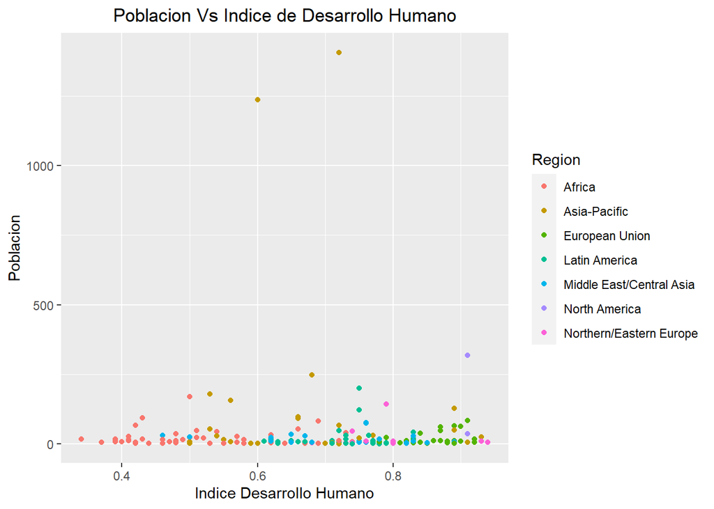

```r
   ggplot(data = idh, aes(x = HDI, y = Poblacion, color = Region)) +
    geom_point() +
   ggtitle("Poblacion Vs Indice de Desarrollo Humano") +
   theme(plot.title = element_text(hjust = 0.5)) +
            labs(x =  "Indice Desarrollo Humano", y = "Poblacion")
```

- Podria haber sido intuitivo pensar, que la población podria hacer variar el indice de desarrollo humano, pero no parece hacerlo. Sin embargo, esta gráfica nos permite ver la anomalia poblaciónal que significan la India y China respectivamente, la mayoria del planeta concentra sus números poblaciones en el mismo rango exceptuando estos dos paises.

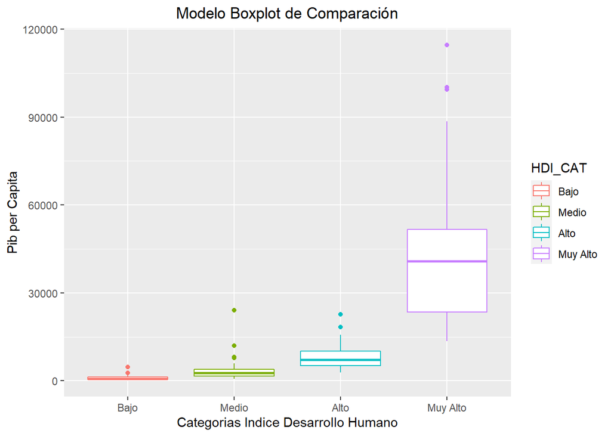

```r
ggplot(data = idh, aes(x = HDI_CAT, y = PibPerCap_, color = HDI_CAT)) +
    geom_boxplot() +
   ggtitle("Modelo Boxplot de Comparación") +
   theme(plot.title = element_text(hjust = 0.5)) +
            labs(x = "Categorias Indice Desarrollo Humano", y = "Pib per Capita")
```

- De manera similar a lo ocurrido con la huella ecólogica, podemos ver como a mayor valores del indice de desarrolo humano mayor es el Pib per Capita. Otra vez llama la atencion la alta variabilidad mostrada por la caja que representa el valor de Idh muy alto. Y como para los demás valores, dicha variabilidad no es tan pronunciada. El caso extremo es para indices bajos, donde la mayoria de los datos estan concentrados alrededor de la media. Suponiendo pocas diferencias en los PIB de estos paises con bajo nivel de Idh.

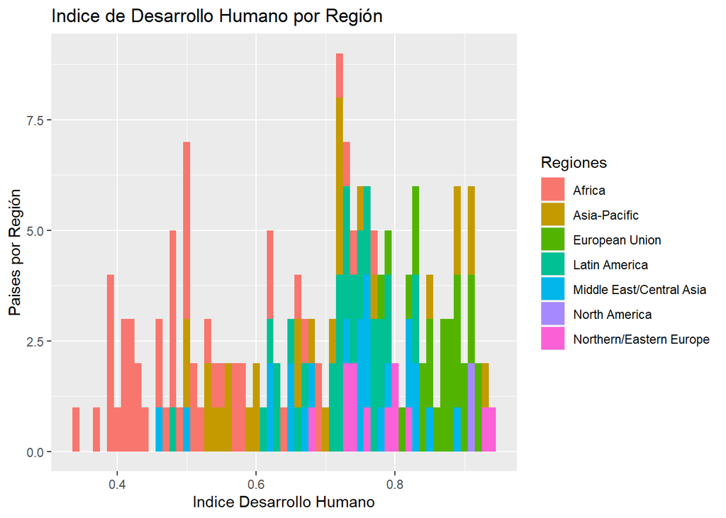

```r
ggplot(idh) +
   geom_histogram(mapping = aes(HDI, fill = Region), binwidth = 0.01) +
   ggtitle("Indice de Desarrollo Humano por Región") +
   labs(x = "Indice Desarrollo Humano", fill = "Regiones", y = "Paises por Región")
```

- Otra visualización interesante, es ver como se distribuye por regiones los valores de **Indice de Desarrollo Humano**, lo primero que llama la atención, es que no hay ningun pais de america del norte, ni de la Union Europea con valores por debajo del 0,7, en la situación opuesta se encuentra Africa, donde apenas hay paises por encima de un nivel bajo-medio de indice de desarrollo humano.
- A partir de aquí, a través de análisis visual, y otros tipo de test, vamos a intentar averiguar que tipo de distribución siguen las variables que estamos estudiando.

**Una vez ya habiamos hecho la exploración de manera individualizada para cada variable, se descubrio existen formas automatizadas de hacer visualizaciones" añadimos dichas visualizaciones aqui abajo**.

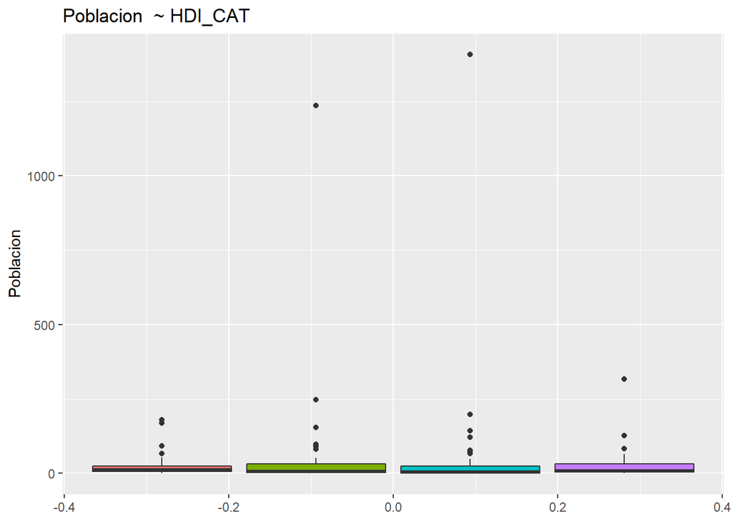

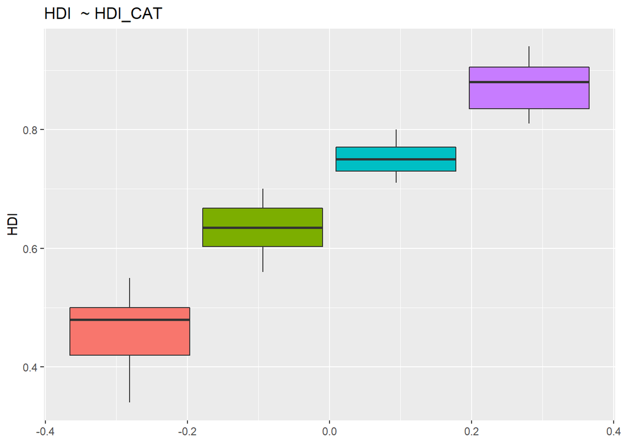

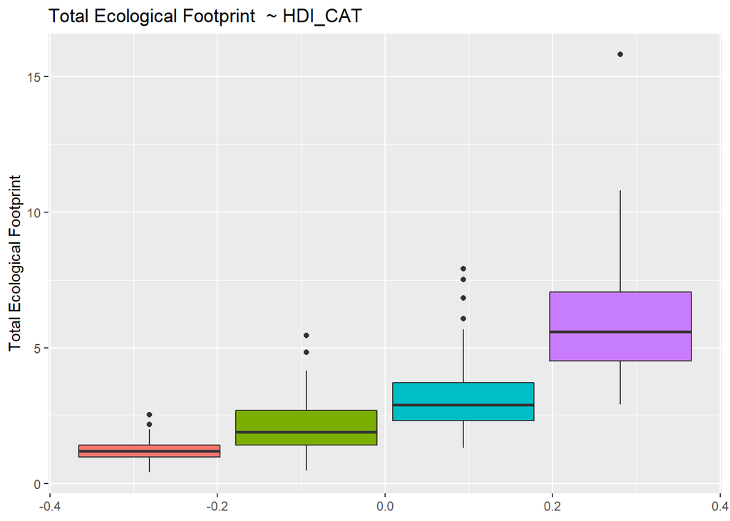

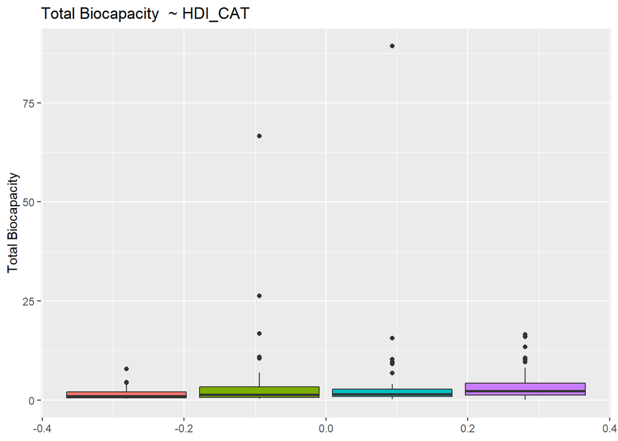

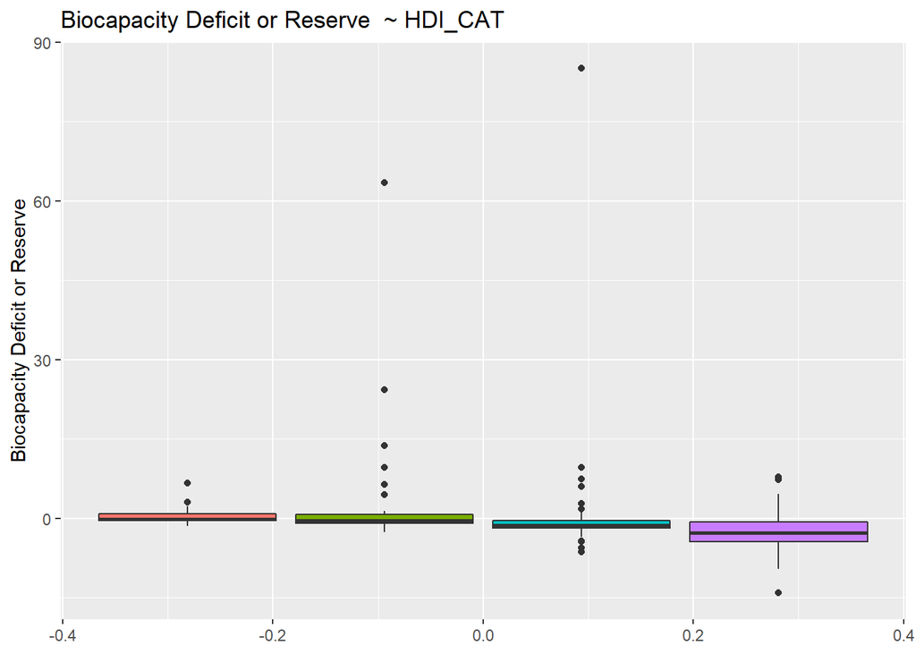

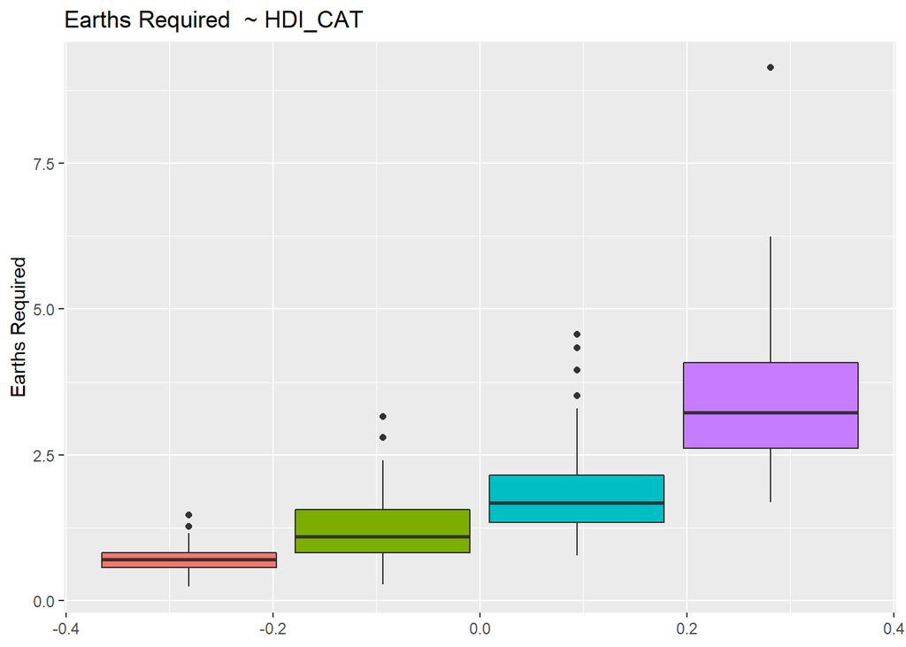

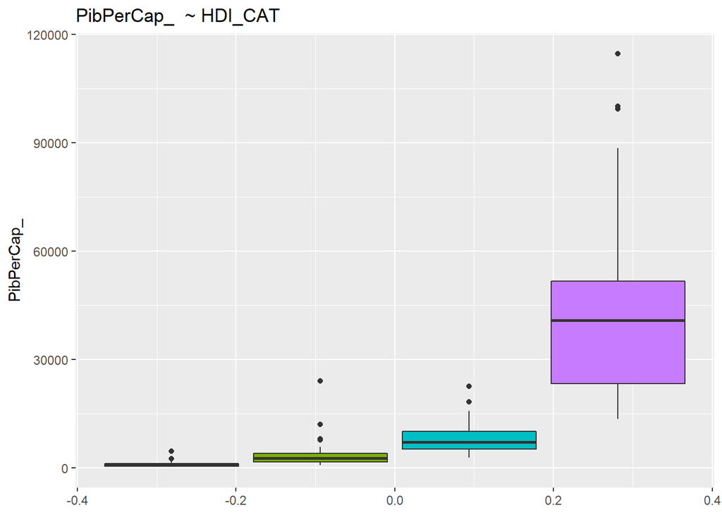

```r
variable.objetivo2 <- function(dataframe.object, target.feature){

  for (columna in 3:ncol(dataframe.object)){

    if (names(dataframe.object[columna]) == "HDI_CAT"){
      next

    } else {
      if (class(dataframe.object[, columna]) == "factor"){
        plotidh1 <- ggplot(dataframe.object) +
          geom_bar(aes(dataframe.object[, columna], fill = as.factor(target.feature))) +
          labs(title=paste(names(dataframe.object[columna]), " ~ HDI_CAT")) +
          xlab(names(dataframe.object[columna])) +
          ylab("Frecuencia") +
          scale_fill_discrete(name="Indice Desarrollo Humano", breaks=c("0.55", "0.70", "0.80", "1"),
                           labels=c("Bajo", "Medio", "Alto", "Muy Alto"))

      } else {
        plotidh1 <- ggplot(dataframe.object) +
          geom_boxplot(aes(dataframe.object[, columna], fill = as.factor(target.feature))) +
          coord_flip() +
          labs(title=paste(names(dataframe.object[columna]), " ~ HDI_CAT")) +
          xlab(names(dataframe.object[columna])) +
          scale_fill_discrete(name="Indice Desarrollo Humano", breaks=c("0.55", "0.70", "0.80", "1"),
                           labels=c("Bajo", "Medio", "Alto", "Muy Alto"))
      }
      plotidh <- print(plotidh1)
    }
  }
}

variable.objetivo2(dataframe.object = idh, target.feature = idh$HDI_CAT)
```

Estudio de normalidad

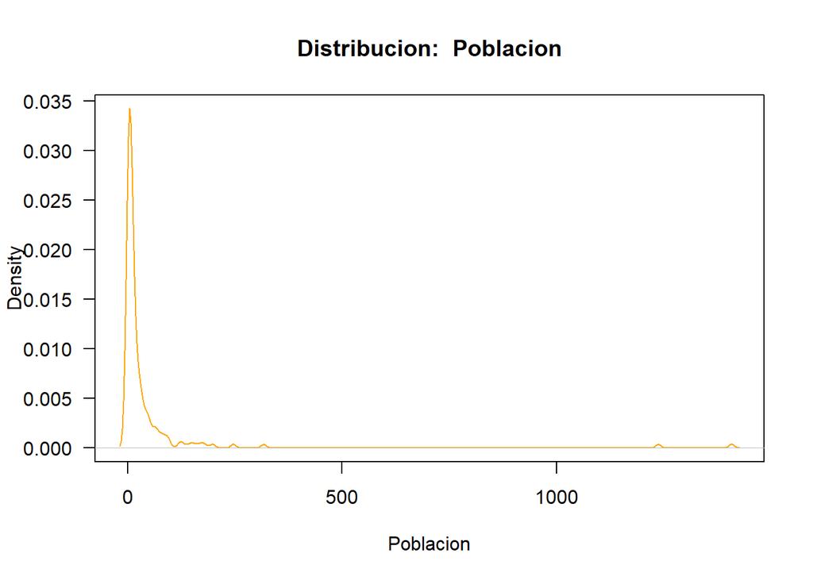

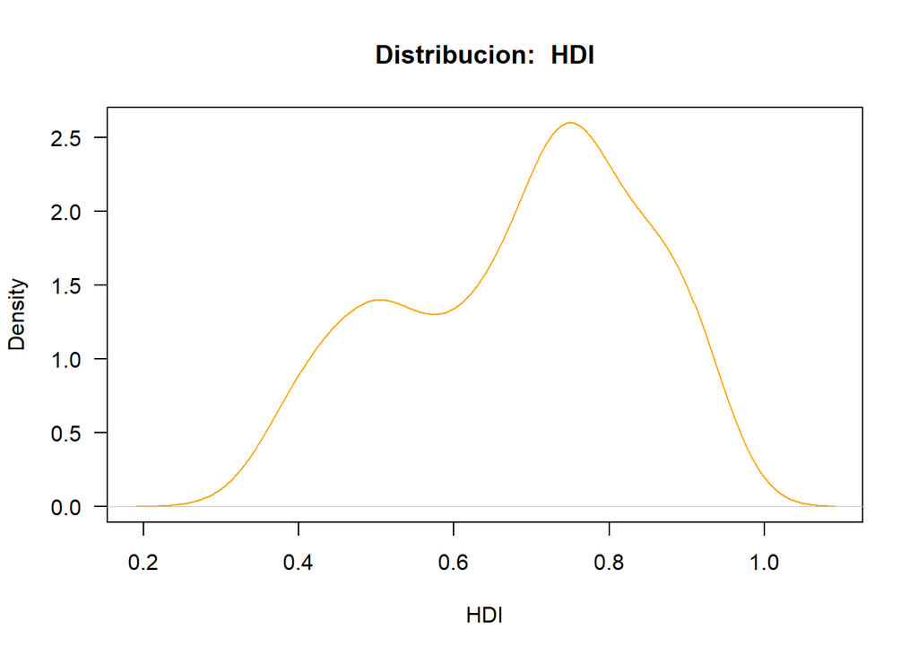

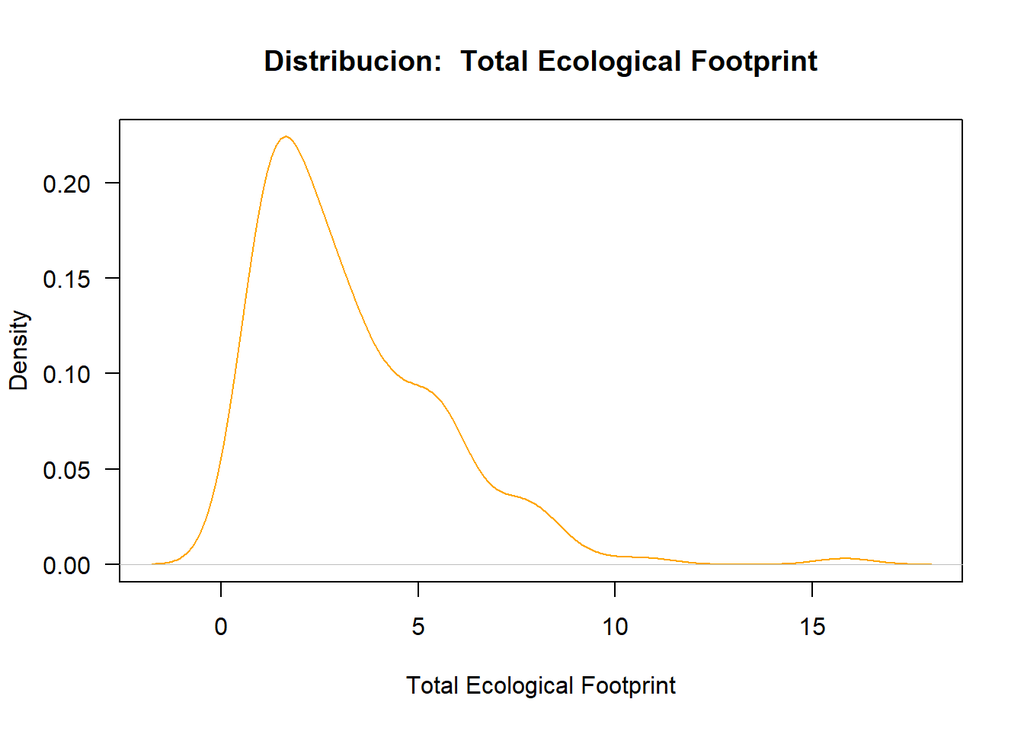

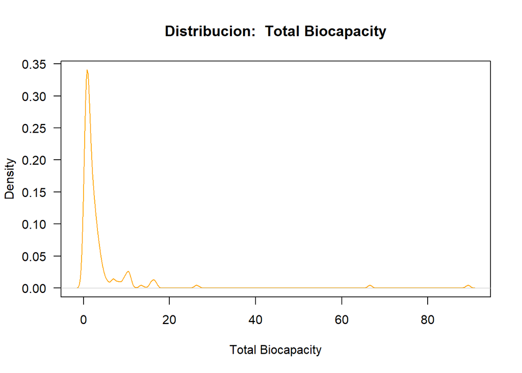

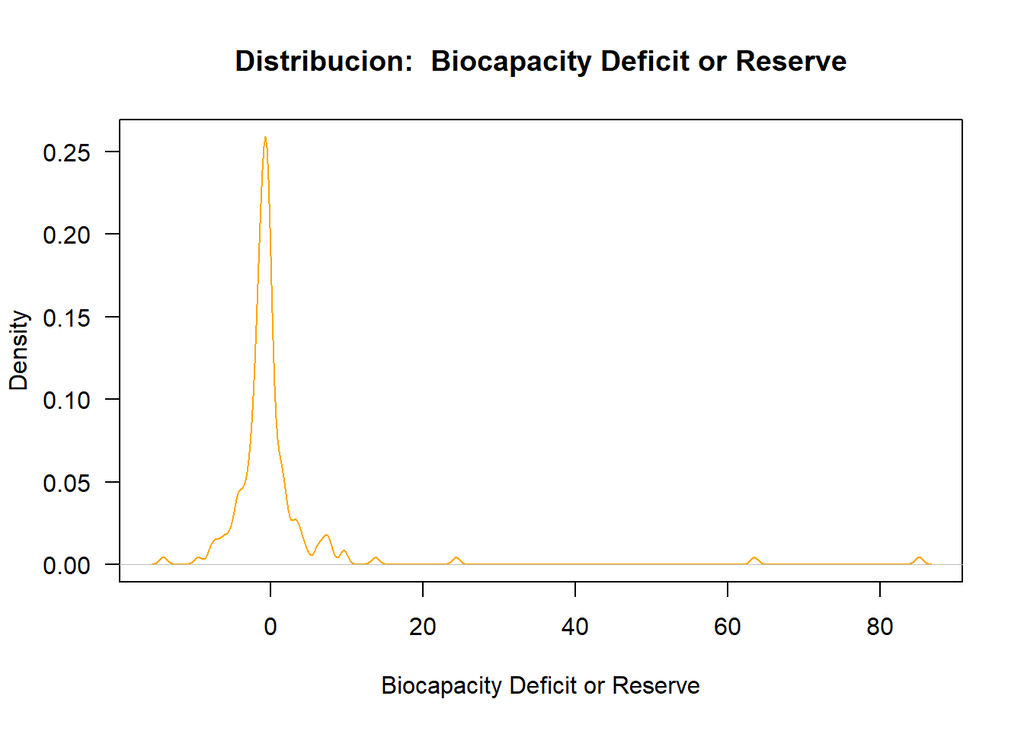

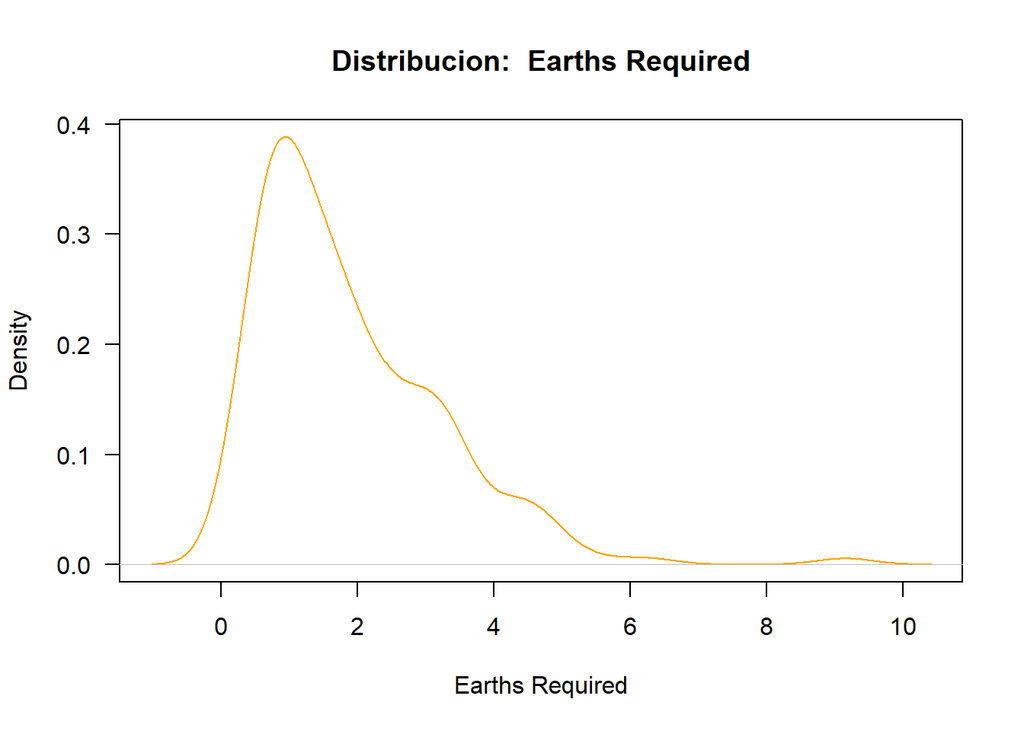

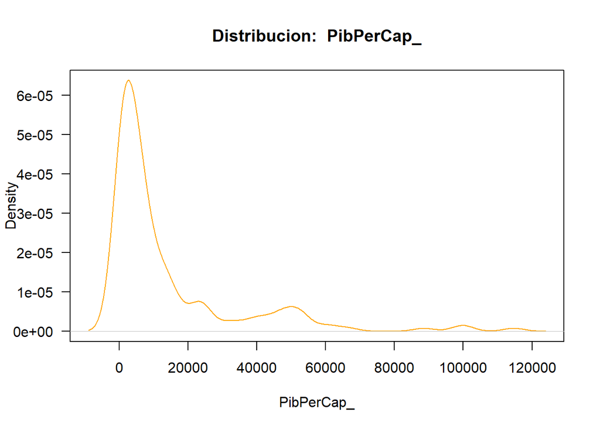

```r
for (columna in 3:ncol(idh)){
  if (class(idh[,columna]) != "factor"){
    plot(density(idh[, columna]),
         col = "orange",
         las = 1,
         main = paste("Distribucion: ", colnames(idh[columna])),
         xlab  = colnames(idh[columna]))
  }
}
```

```r
histDenNorm <- function (x, ...) {
   hist(x, ...) # Histograma
   lines(density(x), col = "blue", lwd = 2) # Densidad
   x2 <- seq(min(x), max(x), length = 172)
   f <- dnorm(x2, mean(x), sd(x))
   lines(x2, f, col = "red", lwd = 2) # Normal
   legend("topright", c("Histograma", "Densidad", "Normal"), box.lty = 0,
          lty = 1, col = c("black", "blue", "red"), lwd = c(1, 2, 2))
}
```